# Compiling statewide PI data for MACRONICHE project

Mike Verhoeven

2019-10-29

```r
  strttime <- Sys.time()
  getwd()
```

```
## [1] "G:/My Drive/Documents/UMN/Grad School/Larkin Lab/R_projects/surveycollation"
```

# Preamble

Load libraries

```r
  library(knitr)
  library(ezknitr)
  library(bit64)
  library(data.table)
  library(tidyr)
  library(stringr)



# load in existing databases ----------------------------------------------
```

## Load in DNR databases

```r
# shallow lakes -----------------------------------------------------------
```

### Shallow Lakes Program

```r
  # shallow lakes data

  sldat <- fread(file = "data/contributor_data/macroniche_adds/muthukrishnan/Lake_plant_diversity_data.csv") # use data.table to pull in dataset

  names(sldat) #view the names within the sldats datatable
```

```
##  [1] "record_num"                 "County_code"
##  [3] "county"                     "lake_id"
##  [5] "lake_name"                  "Lake_acres"
##  [7] "survey_id"                  "survey_year"
##  [9] "survey_date"                "sample_point_num"
## [11] "sample_point_surveyed"      "depth_ft"
## [13] "secchi_ft"                  "substrate"
## [15] "veg_code"                   "vegetation_scientific_name"
## [17] "vegetation_common_name"
```

So we can see that the shallow lakes data are in a long form, with each record representing a plant occurrence, and sites with no plant occurrences having a single record with a *no vegetation present* for the species name. Occurrences with unsurveyed points are marked *no* in the *sample_point_surveyed* field.

```r
  #how many points per survey
  sldat[ , .N , .(lake_name, lake_id, survey_date)]
```

```
##            lake_name  lake_id survey_date   N
##    1: Little Prairie 01001600   16-Aug-11  70
##    2:      Horseshoe 01003400   10-Aug-11 131
##    3:            Mud 01003500   17-Jul-14 167
##    4:      Rat House 01005300   25-Jun-14 147
##    5:    Sandy River 01006000   15-Jul-09 126
##   ---
## 1666:         Miller 87010200   19-Jul-05  92
## 1667:         Miller 87010200   07-Jul-10  63
## 1668:         Miller 87010200   16-Jul-13  78
## 1669: Victors Slough 87011600   01-Jul-09  71
## 1670: Victors Slough 87011600   17-Jul-13 111
```

```r
  #can we pull out the wild rice occurrences?
  sldat[ veg_code == "ZIP", .N , .(lake_name, lake_id, survey_date)]
```

```
##        lake_name  lake_id survey_date  N
##   1:   Horseshoe 01003400   10-Aug-11 14
##   2:         Mud 01003500   17-Jul-14  4
##   3:   Rat House 01005300   25-Jun-14 34
##   4: Sandy River 01006000   15-Jul-09 33
##   5:     Flowage 01006100   29-Jul-11 22
##  ---
## 444:        Long 86024600   20-Jul-07  1
## 445:       Smith 86025000   26-Jun-12  1
## 446:       Smith 86025000   18-Jun-13  2
## 447:       Smith 86025000   09-Jun-14  2
## 448:      Curtis 87001600   20-Aug-13  1
```

```r
  sldat[ veg_code == "ZIP", .N , .(lake_name, lake_id)]
```

```
##        lake_name  lake_id  N
##   1:   Horseshoe 01003400 14
##   2:         Mud 01003500  4
##   3:   Rat House 01005300 34
##   4: Sandy River 01006000 33
##   5:     Flowage 01006100 22
##  ---
## 349:         Mud 86008500  2
## 350:     Malardi 86011200  5
## 351:        Long 86024600  1
## 352:       Smith 86025000  5
## 353:      Curtis 87001600  1
```

```r
  sldat[ veg_code == "ZIP", .N , ]
```

```
## [1] 9245
```

can we cruise these for bad DOWIDs?

```r
  # badIDs <- fread(file = "data/input/Bad DOWIDs.csv", fill = T)
  #
  # idents <- sldat [ , .(unique(lake_name)),]
  #
  # match(badIDs$lake_name,idents$V1) #so we can see that every line has a good match
  # rm(badIDs)
  # rm(idents)
```

All of these bad idents came from the shallow lakes dataset, but there are no spatial data in the shallow lakes data… So there’s really no way to resolve by pulling those data. We’ll have to try to link up to the NWI dataset to get locs on these lakes.

```r
# fisheries div -----------------------------------------------------------
```

### Fisheries Program

Now we want to pull in the next dataset. These are PIs from the Fisheries division.

```r
  # fisheries data

  fshdat <- fread(file = "data/contributor_data/macroniche_adds/dustin/FishDat.csv")

  #need to melt this guy
  #' Now we need to reshape this behemoth...
  names(fshdat)
```

```
##   [1] "OBJECTID"         "SORT_NAME"        "SC_ID"
##   [4] "SS_ID"            "FW_ID"            "DOWLKNUM"
##   [7] "LAKE_NAME"        "DNR_OFFICE"       "SLICE_lake"
##  [10] "STA_CODE"         "STA_NBR"          "STA_ID0"
##  [13] "UTMX"             "UTMY"             "UTM_DATUM"
##  [16] "UTM_ZONE"         "TARGET_LOC"       "ACTUAL_LOC"
##  [19] "UTM_SOURCE"       "DATA_SOURCE"      "SURVEY_ID"
##  [22] "YEAR"             "SURVEYDATE"       "SURVEY_STATUS"
##  [25] "PROJECT"          "SURVEYOR"         "SAMPLETYPE"
##  [28] "LOC_TYPE"         "DEPTH_FT"         "SUBSTRATE"
##  [31] "HAS_DATA"         "E_ACEX"           "E_ALG"
##  [34] "E_ALS"            "E_AT"             "E_BUB"
##  [37] "E_CP"             "E_DA"             "E_EA"
##  [40] "E_EF"             "E_ELEOB"          "E_ELEOC"
##  [43] "E_ELEOE"          "E_ELEOF"          "E_ELEOG"
```

[output cut: 101 more lines]

```r
  #drop species count cols
  fshdat[ ,c(265, 340:347):= NULL , ]

  #find an indicator col for sample taken
  fshdat[, summary(as.factor(HAS_DATA)), ] #according to the metadata record, this will not help us X, Y, Z all
```

```
##     X     Y     Z
##   453 31771 31778
```

```r
  fshdat[ , summary(DEPTH_FT), ]
```

```
##    Min. 1st Qu.  Median    Mean 3rd Qu.    Max.    NA's
##   0.000   3.400   6.000   7.722  10.000 651.000      60
```

```r
  fshdat[ , 32:338 , ][ ,sum() , ]
```

```
## [1] 0
```

```r
  fshdat[ , vegfound := rowSums(.SD), .SDcols = 32:338]
  # fshdat[, vegfound, ]
  fshdat[ vegfound == 0 , novegfound := 1, ]
  fshdat[is.na(novegfound) == T , novegfound := 0, ]
  fshdat[, vegfound := NULL, ]

  # retain the point ID chars and the depth, then make data long (new row for every observation of a species)
  fshdat_1 = melt(fshdat, id.vars = c(1:31),
               variable.name = "taxon", value.name = "pres" )

  # #rows with Zizania palu:
  # fshdat_1[ taxon == "E_ZIP" & pres == "1", .N, ]
  # fshdat_1[ taxon == "E_ZIP" & pres == "1",, ]
  # fshdat_1[ taxon == "E_ZIP" & pres == "1",.N,.(LAKE_NAME, DOWLKNUM, SURVEYDATE) ]
  # fshdat_1[ taxon == "E_ZIP" & pres == "1",.N,.(LAKE_NAME, DOWLKNUM) ]
```

Alright. Now we have the Fisheries data in a long form. We now want to remove the species with a null occurrence, and somehow retain a line for even those points which have a sample with nothing found or with no sample taken. We can do this by saying remove rows with zeroes for presence. Because we have added the no veg found as a taxon, this will retain a line with no vegfound ofr each case where a sample was taken and no plants recovered on rake. One tricky and seemingly impossible thing that we see in these data is that it appears as though **every** sample point was actually sampled–we can almost certainly assume this is not the case.

```r
  # find out what landed in taxon & pres cols
  fshdat_1[ , summary(taxon) , ]
```

```
##   E_ACEX    E_ALG    E_ALS     E_AT    E_BUB     E_CP     E_DA     E_EA
##    64002    64002    64002    64002    64002    64002    64002    64002
##     E_EF  E_ELEOB  E_ELEOC  E_ELEOE  E_ELEOF  E_ELEOG  E_ELEOI  E_ELEOM
##    64002    64002    64002    64002    64002    64002    64002    64002
##  E_ELEON  E_ELEOO  E_ELEOQ  E_ELEOR  E_ELEOV  E_ELEOW  E_ELEOY    E_ELS
##    64002    64002    64002    64002    64002    64002    64002    64002
##     E_EP     E_ES     E_JB     E_JE     E_JF     E_JN     E_JU     E_LD
##    64002    64002    64002    64002    64002    64002    64002    64002
##   E_PHAU    E_POC     E_SA    E_SAC  E_SAGIM    E_SAL  E_SAXTA     E_SB
##    64002    64002    64002    64002    64002    64002    64002    64002
##     E_SC    E_SCF    E_SCH  E_SCHOP  E_SCHOS  E_SCHOX    E_SCP    E_SCT
##    64002    64002    64002    64002    64002    64002    64002    64002
##     E_SE     E_SG   E_SPAM  E_SPARA    E_SPC   E_SPGL     E_SR     E_SV
##    64002    64002    64002    64002    64002    64002    64002    64002
##     E_TA     E_TG     E_TL    E_ZIP  E_ZIZAA    F_BRS    F_CAT     F_NL
##    64002    64002    64002    64002    64002    64002    64002    64002
##     F_NO    F_NUL    F_NUR     F_NV     F_NX    F_NYL     F_PN    F_POA
##    64002    64002    64002    64002    64002    64002    64002    64002
##    F_POO     F_SM    F_SPA    F_SPG     R_AM  R_LEMNO  R_LEMNP  R_LEMNT
##    64002    64002    64002    64002    64002    64002    64002    64002
##     R_LM     R_LT     R_RI     R_WC  R_WOLFB    U_RIF    U_SPM    U_SPP
##    64002    64002    64002    64002    64002    64002    64002    64002
##     U_UC     U_UG     U_UI     U_UM     U_UP     U_UR  U_UTRIG     U_UV
##    64002    64002    64002    64002    64002    64002    64002    64002
##    S_CAH     S_CD    S_CEE  (Other)
##    64002    64002    64002 13376418
```

```r
  fshdat_1[ , summary(pres) , ]
```

```
##     Min.  1st Qu.   Median     Mean  3rd Qu.     Max.
## 0.000000 0.000000 0.000000 0.006076 0.000000 1.000000
```

```r
  #drop all of the zeros (not observed) in this plant
  fshdat_2 <- fshdat_1[pres > 0,] # retain only rows with pres > 0
  str(fshdat_2)
```

```
## Classes 'data.table' and 'data.frame':   119772 obs. of  33 variables:
##  $ OBJECTID     : int  56592 59503 63857 55694 59768 61136 64350 66485 67512 67660 ...
##  $ SORT_NAME    : chr  "Prairie VP142 8/31/2015" "Antoinette VP86 10/13/2014" "Unnamed VP38 9/19/2016" "Twenty-One VP66 7/27/2015" ...
##  $ SC_ID        :integer64 14081518830707076 10011420547062102 14081617540688496 12541521253774026 3960923239684189 10011420349722118 13061627950264085 3871020931216002 ...
##  $ SS_ID        :integer64 13581517729569141 10181420235092085 12131616558183037 11981520554942065 3280808434109397 10181420235092091 13061627849992030 3280817853547384 ...
##  $ FW_ID        : int  2115 9575 9229 1674 2535 9575 4180 819 819 2428 ...
##  $ DOWLKNUM     : int  69084800 69022500 69062500 29013000 18038600 69022500 58002400 69025400 69025400 9003800 ...
##  $ LAKE_NAME    : chr  "Prairie" "Antoinette" "Unnamed" "Twenty-One" ...
##  $ DNR_OFFICE   : chr  "Duluth" "Duluth" "Duluth" "Park Rapids" ...
##  $ SLICE_lake   : chr  "N" "N" "N" "N" ...
##  $ STA_CODE     : chr  "VP" "VP" "VP" "VP" ...
##  $ STA_NBR      : int  142 86 38 66 102 92 30 130 286 89 ...
##  $ STA_ID0      : chr  "VP142" "VP86" "VP38" "VP66" ...
##  $ UTMX         : num  508544 566945 537572 360462 400799 ...
##  $ UTMY         : num  5181938 5192022 5201612 5224774 5136109 ...
```

[output cut: 20 more lines]

```r
  #now convert these codes to taxonomic names
  fshdat_2[ , sort(unique(taxon)), ]
```

```
##   [1] E_CP       E_DA       E_EA       E_EF       E_ELS      E_ES
##   [7] E_LD       E_PHAU     E_POC      E_SA       E_SAL      E_SC
##  [13] E_SCF      E_SCHOX    E_SCP      E_SE       E_SG       E_SPAM
##  [19] E_SPC      E_SR       E_SV       E_TA       E_TL       E_ZIP
##  [25] F_BRS      F_NL       F_NO       F_NUL      F_NV       F_NX
##  [31] F_PN       F_POA      F_SPA      F_SPG      R_LEMNT    R_LM
##  [37] R_LT       R_WC       U_SPM      U_SPP      U_UG       U_UI
##  [43] U_UM       U_UP       U_UV       S_CD       S_CEE      S_EC
##  [49] S_ELM      S_EN       S_HD       S_HV       S_IE       S_LU
##  [55] S_MA       S_MB       S_MS       S_MYS      S_MYT      S_N
##  [61] S_NAG      S_NF       S_NG       S_NM       S_PA       S_PC
##  [67] S_PD       S_PE       S_PF       S_PG       S_PI       S_PO
##  [73] S_POAL     S_POB      S_POFR     S_PON      S_POP      S_POPU
##  [79] S_POR      S_POS      S_POV      S_PP       S_PR       S_PS
##  [85] S_PV       S_PZ       S_RAF      S_RF       S_RL       S_SS
##  [91] S_VA       S_ZP       T_AC       T_AG       T_AI       T_BA
##  [97] T_BB       T_CA       T_CAC      T_CALA     T_CAP      T_CB
## [103] T_CHC      T_GB       T_HYV      T_IV       T_JEWL     T_LA
## [109] T_LS       T_LYT      T_MG       T_MT       T_PHA      T_PL
## [115] T_POPA     T_SCA      T_SCC      T_SIS      T_VES      EG_AL
## [121] EG_ELNE    EG_ELSP    EG_EQS     EG_J       EG_S       EG_SAS
## [127] EG_SCS     EG_SCTS    EG_SEME    EG_TS      EG_ZIZA    FG_NUS
## [133] FG_NYS     FG_P       FG_SFLO    RG_BGA     RG_FA      RG_LEMN
## [139] RG_WS      UG_BW      UG_SPAG    UG_WM      SG_C       SG_D
## [145] SG_ELAS    SG_ELOD    SG_H       SG_I       SG_M       SG_N
## [151] SG_NS      SG_PONF    SG_POSB    SG_POSN    SG_R       SG_SPNG
## [157] TG_A       TG_ACOR    TG_B       TG_CAN     TG_CS      TG_CYP
## [163] TG_EUTR    TG_F       TG_G       TG_IMS     TG_IS      TG_LAB
## [169] TG_LYS     TG_RU      TG_SO      TG_SX      novegfound
## 308 Levels: E_ACEX E_ALG E_ALS E_AT E_BUB E_CP E_DA E_EA E_EF ... novegfound
```

```r
  fshdat_2[ , taxon := word(taxon, start = -1, sep = fixed("_")), ]

  fish_codes <- fread(file = "data/contributor_data/macroniche_adds/dustin/fisheries_codes_MRV.csv")

  #these fish data have a field for no species found
  a <- data.table(SCIENTIFIC_NAME = "No Veg Found", PLANT_SPECIES_ABBREV = "novegfound")
  fish_codes <- rbind(fish_codes[, 3:4],a)

  # CHECK MATCHES
  # match(fshdat_2$taxon, fish_codes$PLANT_SPECIES_ABBREV)

  fshdat_2[ , taxonfull := fish_codes$SCIENTIFIC_NAME[match(fshdat_2$taxon, fish_codes$PLANT_SPECIES_ABBREV)] , ]

  fshdat_2[ , sort(unique(taxonfull)), ]
```

```
##   [1] "Acorus americanus"                "Acorus sp."
##   [3] "Alisma sp."                       "Alnus sp."
##   [5] "Andromeda glaucophylla"           "Asclepias incarnata"
##   [7] "Betula pumila"                    "Bidens beckii"
##   [9] "Bidens sp."                       "Bolboschoenus fluviatilis"
##  [11] "Boltonia asteroides"              "Brasenia schreberi"
##  [13] "Calla palustris"                  "Caltha palustris"
##  [15] "Carex aquatilis"                  "Carex comosa"
##  [17] "Carex lacustris"                  "Carex sp."
##  [19] "Ceratophyllum demersum"           "Ceratophyllum echinatum"
##  [21] "Chamaedaphne calyculata"          "Chara sp."
##  [23] "Cicuta maculata"                  "Cyanobacteria"
##  [25] "Cyperaceae sp."                   "Drepanocladus sp."
##  [27] "Drepanocladus; Fontinalis; etc"   "Dulichium arundinaceum"
##  [29] "Elatine minima"                   "Elatine sp."
```

[output cut: 70 more lines]

```r
  #remove previous versions datafiles from workspace
  rm(fshdat, fshdat_1,fish_codes,a)


# lakes and rivers --------------------------------------------------------
```

### Lakes and Rivers Program

```r
  # lnr data

  lnrdat <- fread(file = "data/contributor_data/macroniche_adds/perleberg/LakePlant export 20190701 finalql.csv")

  names(lnrdat)
```

```
##  [1] "Project::STATUS"            "SURVEY_ID"
##  [3] "DOWLKNUM"                   "LAKE_NAME"
##  [5] "STA_NBR"                    "SURVEY_DATE"
##  [7] "SAMPLE_TYPE_DESCR"          "DEPTH"
##  [9] "GPScoords::POINT_SPACING_M" "SUBSTRATE"
## [11] "VEG_REL_ABUNDANCE_DESCR"    "SURVEYOR_A"
## [13] "SURVEYOR_B"                 "SURVEYOR_C"
## [15] "SAMPLE_NOTES"               "TAXA_NUMBER"
## [17] "OBSERVED_TAXA"              "OBSERVED_TAXA_REL_ABUND"
## [19] "GPScoords::UTMX"            "GPScoords::UTMY"
## [21] "GPScoords::SURVEY_ID"
```

```r
  lnrdat[ , .N , .(LAKE_NAME, SURVEY_DATE, DOWLKNUM)]
```

```
##           LAKE_NAME SURVEY_DATE DOWLKNUM   N
##   1:            Dam  06/28/2002  1009600  81
##   2:            Dam  07/02/2002  1009600  78
##   3:       Big Pine  08/14/2013  1015700  52
##   4:       Big Pine  08/15/2013  1015700  71
##   5:       Big Pine  08/12/2013  1015700 113
##  ---
## 440: Little Waverly  08/18/2009 86010600  57
## 441:        Waverly  06/03/2004 86011400 227
## 442:        Waverly  08/17/2009 86011400 159
## 443:    Little Mary  06/27/2005 86013900 203
## 444:    Little Mary  06/06/2006 86013900 203
```

```r
  summary <- lnrdat[ , .N , .(LAKE_NAME, SURVEY_DATE, DOWLKNUM)]

  # write.csv(summary, file = "lnrsurveysummary.csv")

  lnrdat[ , .N , .(LAKE_NAME, SURVEY_DATE, DOWLKNUM)]
```

```
##           LAKE_NAME SURVEY_DATE DOWLKNUM   N
##   1:            Dam  06/28/2002  1009600  81
##   2:            Dam  07/02/2002  1009600  78
##   3:       Big Pine  08/14/2013  1015700  52
##   4:       Big Pine  08/15/2013  1015700  71
##   5:       Big Pine  08/12/2013  1015700 113
##  ---
## 440: Little Waverly  08/18/2009 86010600  57
## 441:        Waverly  06/03/2004 86011400 227
## 442:        Waverly  08/17/2009 86011400 159
## 443:    Little Mary  06/27/2005 86013900 203
## 444:    Little Mary  06/06/2006 86013900 203
```

```r
  int <- data.table(sp = rep("sp", 15), num = 1:15)

  int[ , spnum := paste(sp,num, sep = "")]

  lnrdat_1 <- separate(lnrdat, OBSERVED_TAXA, into = c(int$spnum) )
  names(lnrdat_1)
```

```
##  [1] "Project::STATUS"            "SURVEY_ID"
##  [3] "DOWLKNUM"                   "LAKE_NAME"
##  [5] "STA_NBR"                    "SURVEY_DATE"
##  [7] "SAMPLE_TYPE_DESCR"          "DEPTH"
##  [9] "GPScoords::POINT_SPACING_M" "SUBSTRATE"
## [11] "VEG_REL_ABUNDANCE_DESCR"    "SURVEYOR_A"
## [13] "SURVEYOR_B"                 "SURVEYOR_C"
## [15] "SAMPLE_NOTES"               "TAXA_NUMBER"
## [17] "sp1"                        "sp2"
## [19] "sp3"                        "sp4"
## [21] "sp5"                        "sp6"
## [23] "sp7"                        "sp8"
## [25] "sp9"                        "sp10"
## [27] "sp11"                       "sp12"
## [29] "sp13"                       "sp14"
## [31] "sp15"                       "OBSERVED_TAXA_REL_ABUND"
## [33] "GPScoords::UTMX"            "GPScoords::UTMY"
## [35] "GPScoords::SURVEY_ID"
```

```r
  lnrdat_1[ , OBSERVED_TAXA_REL_ABUND := NULL]# drop unneeded col


  lnrdat_1[sp1 == "" , summary(as.factor(VEG_REL_ABUNDANCE_DESCR)) , ]# deal with locs where no veg was found.
```

```
##               no sample vegetation not detected
##                    2468                   22707
```

```r
  lnrdat_2 <-  melt(lnrdat_1, id.vars = c(1:16, 32:34))
```

We’ll want to simplify these and drop unsampled sites from the data, also reevaluate what to do with the “sampled subjective sites”, “shoreline surveys.” For now, I have dropped all of these

```r
  lnrdat_2[ , SAMPLE_TYPE_DESCR := as.factor(SAMPLE_TYPE_DESCR), ]
  lnrdat_2[, summary(SAMPLE_TYPE_DESCR) , ]
```

```
##             no sample - emergents                 no sample - other
##                             12525                               990
##                 no sample - shore              no sample - too deep
##                              7635                             26250
##                           sampled sampled - offgrid subjective site
##                            914595                              1785
##          sampled - shoreline plot
##                              2955
```

```r
  lnrdat_3 <- lnrdat_2[SAMPLE_TYPE_DESCR == "sampled" , , ]

  lnrdat_3[ , SAMPLE_NOTES := as.factor(SAMPLE_NOTES), ]
  lnrdat_3[ SAMPLE_NOTES != "", .(SAMPLE_NOTES), ]
```

```
##                          SAMPLE_NOTES
##     1:                        rip rap
##     2:                       gr heron
##     3:                         sponge
##     4:                   mostly _Sand
##     5:                        rip rap
##    ---
## 10946: Curly Leaf formed surface mats
## 10947: Curly leaf formed surface mats
## 10948: Curly leaf formed surface mats
## 10949: Curly leaf formed surface mats
## 10950:                            emt
```

```r
  lnrdat_3[ , VEG_REL_ABUNDANCE_DESCR := as.factor(VEG_REL_ABUNDANCE_DESCR),  ]
  lnrdat_3[ , summary(VEG_REL_ABUNDANCE_DESCR),]
```

```
##                                       abundant/matted
##                     543480                       2655
## common/frequent/occasional                     sparse
##                      18375                      10020
##    vegetation not detected
##                     340065
```

We need to delete all of the na’s that come from expanding our data, but we don’t want to lose a line of data for points where no veg was found. Luckily we have a “” (blank) for spoecies one from our melt function. So, every row with value ==NA can get hucked out.

```r
  lnrdat_3[VEG_REL_ABUNDANCE_DESCR != 'vegetation not detected', ,]#locs not labeled as veg not det
```

```
##         Project::STATUS       SURVEY_ID DOWLKNUM   LAKE_NAME STA_NBR
##      1:        FINAL_QL 01009600_2002_1  1009600         Dam       1
##      2:        FINAL_QL 01009600_2002_1  1009600         Dam       2
##      3:        FINAL_QL 01009600_2002_1  1009600         Dam       3
##      4:        FINAL_QL 01009600_2002_1  1009600         Dam       4
##      5:        FINAL_QL 01009600_2002_1  1009600         Dam       5
##     ---
## 574526:        FINAL_QL 86013900_2006_1 86013900 Little Mary     182
## 574527:        FINAL_QL 86013900_2006_1 86013900 Little Mary     188
## 574528:        FINAL_QL 86013900_2006_1 86013900 Little Mary     194
## 574529:        FINAL_QL 86013900_2006_1 86013900 Little Mary     199
## 574530:        FINAL_QL 86013900_2006_1 86013900 Little Mary     202
##         SURVEY_DATE SAMPLE_TYPE_DESCR DEPTH GPScoords::POINT_SPACING_M
##      1:  06/28/2002           sampled   1.5                        100
##      2:  06/28/2002           sampled   4.0                        100
```

[output cut: 45 more lines]

```r
  lnrdat_4 <- lnrdat_3[is.na(value) == F]


  # lookup scientific names
  lnrdat_4[ , variable := NULL , ]
  lnrdat_4[ , TAXA_NUMBER := NULL , ]

  lnrdat_4[ , sort(unique(value)), ]
```

```
##   [1] ""         "AC"       "BB"       "BRS"      "C"        "CA"
##   [7] "CALAMA"   "CD"       "CEE"      "CP"       "CS"       "DA"
##  [13] "DREPADUN" "EA"       "EC"       "EF"       "ELM"      "ELNE"
##  [19] "ELS"      "ELSP"     "ES"       "FONTSULL" "G"        "HD"
##  [25] "HV"       "I"        "IS"       "IV"       "JP"       "LD"
##  [31] "LEMN"     "LS"       "LT"       "M"        "MB"       "MF"
##  [37] "MS"       "MV"       "MYS"      "MYT"      "N"        "NF"
##  [43] "NG"       "NO"       "NS"       "NV"       "PA"       "PC"
##  [49] "PE"       "PG"       "PHA"      "PHAU"     "PI"       "PN"
##  [55] "POA"      "POAL"     "POC"      "POF"      "POFR"     "PON"
##  [61] "POP"      "POPU"     "POR"      "POSN"     "POV"      "PP"
##  [67] "PR"       "PS"       "PZ"       "R"        "RAF"      "SAL"
##  [73] "SAS"      "SC"       "SCA"      "SCF"      "SCORSCOR" "SCS"
##  [79] "SCSTRI"   "SE"       "SEME"     "SFLO"     "SG"       "SPA"
##  [85] "SPAM"     "SPP"      "SR"       "SS"       "TA"       "TL"
##  [91] "TS"       "UG"       "UI"       "UM"       "UV"       "VA"
##  [97] "WC"       "WM"       "WS"       "X"        "ZIP"      "ZM"
## [103] "ZP"
```

```r
  lnrtaxa <- fread(file = "data/contributor_data/macroniche_adds/perleberg/taxalist.csv")
  #mndnr exported all rare species as "X" so we'll need to add this to the taxalist
  lnrtaxa <- rbind(lnrtaxa,data.table(SCIENTIFIC_NAME = "Rare Species", TAXA_CODE = "X"))

  # # check matches
  # match(lnrdat_4$value, lnrtaxa$TAXA_CODE)

  lnrdat_4[ , taxon := lnrtaxa$SCIENTIFIC_NAME[match(lnrdat_4$value, lnrtaxa$TAXA_CODE)] , ]

  lnrdat_4[ , sort(unique(taxon)), ]
```

```
##  [1] "Acorus americanus"
##  [2] "Betula pumila"
##  [3] "Bidens beckii"
##  [4] "Bolboschoenus fluviatilis"
##  [5] "Brasenia schreberi"
##  [6] "Calla palustris"
##  [7] "Carex"
##  [8] "Carex aquatilis"
##  [9] "Ceratophyllum demersum"
## [10] "Ceratophyllum echinatum"
## [11] "Chara"
## [12] "Dreissena polymorpha"
## [13] "Drepanocladus aduncus"
## [14] "Dulichium arundinaceum var. arundinaceum"
## [15] "Elatine minima"
```

[output cut: 84 more lines]

```r
  lnrdat_4[ VEG_REL_ABUNDANCE_DESCR == "vegetation not detected" , summary(as.factor(value)), ]
```

```
##          ZM
## 22666     5
```

```r
  #remove datafiles from substeps
  rm(lnrdat_1, lnrdat_2, lnrdat_3, lnrdat, lnrtaxa, int, summary)


# clean datasets to prep for merge ----------------------------------------
```

## Prep datasets for merge

```r
# drop unused or re-creatable columns  -------------------------------------------------------
```

### Drop unneeded columns

```r
  summary(fshdat_2)
```

```
##     OBJECTID       SORT_NAME             SC_ID
##  Min.   : 55148   Length:119772      Min.   :   40813348164000
##  1st Qu.: 71021   Class :character   1st Qu.: 2401123736044079
##  Median : 87167   Mode  :character   Median : 3751122239790120
##  Mean   : 86785                      Mean   : 4992711487202657
##  3rd Qu.:103023                      3rd Qu.: 5301216541636013
##  Max.   :119149                      Max.   :14841533443045155
##
##      SS_ID                       FW_ID          DOWLKNUM
##  Min.   :           123871   Min.   :  568   Min.   : 1000100
##  1st Qu.: 3280808434248686   1st Qu.: 2535   1st Qu.:13008300
##  Median : 3280817853547460   Median : 3344   Median :29025000
##  Mean   : 4579181615358228   Mean   : 3589   Mean   :35382637
##  3rd Qu.: 5011417530265280   3rd Qu.: 3988   3rd Qu.:58002400
##  Max.   :14841532745663312   Max.   :17035   Max.   :86027100
##
##   LAKE_NAME          DNR_OFFICE         SLICE_lake
##  Length:119772      Length:119772      Length:119772
##  Class :character   Class :character   Class :character
##  Mode  :character   Mode  :character   Mode  :character
##
##
##
##
##    STA_CODE            STA_NBR         STA_ID0               UTMX
##  Length:119772      Min.   :   1.0   Length:119772      Min.   :230018
##  Class :character   1st Qu.:  63.0   Class :character   1st Qu.:359242
##  Mode  :character   Median : 152.0   Mode  :character   Median :436325
##                     Mean   : 212.3                      Mean   :434808
##                     3rd Qu.: 295.0                      3rd Qu.:510356
##                     Max.   :1341.0                      Max.   :712374
##                                                         NA's   :4680
##       UTMY           UTM_DATUM     UTM_ZONE  TARGET_LOC     ACTUAL_LOC
##  Min.   :4828777   Min.   :83   Min.   :15   Mode:logical   Mode:logical
##  1st Qu.:5020684   1st Qu.:83   1st Qu.:15   NA's:119772    NA's:119772
##  Median :5084878   Median :83   Median :15
##  Mean   :5093033   Mean   :83   Mean   :15
##  3rd Qu.:5203700   3rd Qu.:83   3rd Qu.:15
##  Max.   :5310041   Max.   :83   Max.   :15
##  NA's   :4680
```

[output cut: 25 more lines]

```
##  Length:119772      Length:119772      Length:119772      Min.   :1
##  Class :character   Class :character   Class :character   1st Qu.:1
##  Mode  :character   Mode  :character   Mode  :character   Median :1
##                                                           Mean   :1
##                                                           3rd Qu.:1
##                                                           Max.   :1
##
##   taxonfull
##  Length:119772
##  Class :character
##  Mode  :character
##
##
##
##
```

```r
  names(fshdat_2)
```

```
##  [1] "OBJECTID"      "SORT_NAME"     "SC_ID"         "SS_ID"
##  [5] "FW_ID"         "DOWLKNUM"      "LAKE_NAME"     "DNR_OFFICE"
##  [9] "SLICE_lake"    "STA_CODE"      "STA_NBR"       "STA_ID0"
## [13] "UTMX"          "UTMY"          "UTM_DATUM"     "UTM_ZONE"
## [17] "TARGET_LOC"    "ACTUAL_LOC"    "UTM_SOURCE"    "DATA_SOURCE"
## [21] "SURVEY_ID"     "YEAR"          "SURVEYDATE"    "SURVEY_STATUS"
## [25] "PROJECT"       "SURVEYOR"      "SAMPLETYPE"    "LOC_TYPE"
## [29] "DEPTH_FT"      "SUBSTRATE"     "HAS_DATA"      "taxon"
## [33] "pres"          "taxonfull"
```

```r
  #drop unused columns
  fshdat_2[ , c("OBJECTID","SORT_NAME", "SC_ID", "SS_ID", "FW_ID", "DNR_OFFICE", "STA_CODE", "STA_ID0", "TARGET_LOC", "ACTUAL_LOC", "UTM_SOURCE", "DATA_SOURCE", "SURVEY_STATUS", "PROJECT", "SAMPLETYPE", "LOC_TYPE", "pres","SLICE_lake","UTM_DATUM", "UTM_ZONE", "YEAR") := NULL , ]

  summary(lnrdat_4)
```

```
##  Project::STATUS     SURVEY_ID            DOWLKNUM
##  Length:118694      Length:118694      Min.   : 1009600
##  Class :character   Class :character   1st Qu.:11020300
##  Mode  :character   Mode  :character   Median :18009000
##                                        Mean   :22560896
##                                        3rd Qu.:30013600
##                                        Max.   :86013900
##
##   LAKE_NAME            STA_NBR       SURVEY_DATE
##  Length:118694      Min.   :   0.0   Length:118694
##  Class :character   1st Qu.: 131.0   Class :character
##  Mode  :character   Median : 357.0   Mode  :character
##                     Mean   : 668.9
##                     3rd Qu.: 830.0
##                     Max.   :8593.0
##
##                          SAMPLE_TYPE_DESCR      DEPTH
##  no sample - emergents            :     0   Min.   : 0.200
##  no sample - other                :     0   1st Qu.: 4.000
##  no sample - shore                :     0   Median : 6.000
##  no sample - too deep             :     0   Mean   : 8.142
##  sampled                          :118694   3rd Qu.:11.000
##  sampled - offgrid subjective site:     0   Max.   :40.000
##  sampled - shoreline plot         :     0   NA's   :48
##  GPScoords::POINT_SPACING_M  SUBSTRATE
##  Min.   :   30.0            Length:118694
##  1st Qu.:   65.0            Class :character
##  Median :   65.0            Mode  :character
##  Mean   :  132.4
##  3rd Qu.:  100.0
##  Max.   :25100.0
##
##                VEG_REL_ABUNDANCE_DESCR  SURVEYOR_A
##                            :90140      Length:118694
##  abundant/matted           :  767      Class :character
##  common/frequent/occasional: 4066      Mode  :character
##  sparse                    : 1050
##  vegetation not detected   :22671
##
##
```

[output cut: 17 more lines]

```
##  Min.   :4897338   Length:118694        Length:118694
##  1st Qu.:5152859   Class :character     Class :character
##  Median :5188230   Mode  :character     Mode  :character
##  Mean   :5172087
##  3rd Qu.:5212316
##  Max.   :5321599
##
##     taxon
##  Length:118694
##  Class :character
##  Mode  :character
##
##
##
##
```

```r
  names(lnrdat_4)
```

```
##  [1] "Project::STATUS"            "SURVEY_ID"
##  [3] "DOWLKNUM"                   "LAKE_NAME"
##  [5] "STA_NBR"                    "SURVEY_DATE"
##  [7] "SAMPLE_TYPE_DESCR"          "DEPTH"
##  [9] "GPScoords::POINT_SPACING_M" "SUBSTRATE"
## [11] "VEG_REL_ABUNDANCE_DESCR"    "SURVEYOR_A"
## [13] "SURVEYOR_B"                 "SURVEYOR_C"
## [15] "SAMPLE_NOTES"               "GPScoords::UTMX"
## [17] "GPScoords::UTMY"            "GPScoords::SURVEY_ID"
## [19] "value"                      "taxon"
```

```r
  #drop unused columns
  lnrdat_4[ , c("Project::STATUS","GPScoords::POINT_SPACING_M", "GPScoords::SURVEY_ID") := NULL , ]

  summary(sldat)
```

```
##    record_num      County_code       county            lake_id
##  Min.   :     1   Min.   : 1.00   Length:197702      Length:197702
##  1st Qu.: 49426   1st Qu.:17.00   Class :character   Class :character
##  Median : 98852   Median :34.00   Mode  :character   Mode  :character
##  Mean   : 98852   Mean   :39.57
##  3rd Qu.:148277   3rd Qu.:61.00
##  Max.   :197702   Max.   :87.00
##
##   lake_name           Lake_acres        survey_id     survey_year
##  Length:197702      Min.   :    0.0   Min.   :2712   Min.   :2002
##  Class :character   1st Qu.:  100.0   1st Qu.:3843   1st Qu.:2007
##  Mode  :character   Median :  235.0   Median :4426   Median :2010
##                     Mean   :  895.9   Mean   :4278   Mean   :2009
##                     3rd Qu.:  675.0   3rd Qu.:4880   3rd Qu.:2012
##                     Max.   :11944.0   Max.   :5298   Max.   :2014
##
##  survey_date        sample_point_num sample_point_surveyed
##  Length:197702      Min.   :  1.00   Length:197702
##  Class :character   1st Qu.: 15.00   Class :character
##  Mode  :character   Median : 32.00   Mode  :character
##                     Mean   : 42.88
##                     3rd Qu.: 54.00
##                     Max.   :528.00
##                     NA's   :2
##     depth_ft        secchi_ft      substrate           veg_code
##  Min.   : 0.000   Min.   : 0.00   Length:197702      Length:197702
##  1st Qu.: 2.500   1st Qu.: 1.50   Class :character   Class :character
##  Median : 3.500   Median : 2.50   Mode  :character   Mode  :character
##  Mean   : 4.164   Mean   : 2.75
##  3rd Qu.: 5.000   3rd Qu.: 3.50
##  Max.   :36.500   Max.   :20.00
##  NA's   :20910    NA's   :36906
##  vegetation_scientific_name vegetation_common_name
##  Length:197702              Length:197702
##  Class :character           Class :character
##  Mode  :character           Mode  :character
##
##
##
##
```

```r
  names(sldat)
```

```
##  [1] "record_num"                 "County_code"
##  [3] "county"                     "lake_id"
##  [5] "lake_name"                  "Lake_acres"
##  [7] "survey_id"                  "survey_year"
##  [9] "survey_date"                "sample_point_num"
## [11] "sample_point_surveyed"      "depth_ft"
## [13] "secchi_ft"                  "substrate"
## [15] "veg_code"                   "vegetation_scientific_name"
## [17] "vegetation_common_name"
```

```r
  #drop unused columns
  sldat[ , c("record_num","County_code", "county", "Lake_acres", "survey_year","vegetation_common_name") := NULL , ]


# clean column names -------------------------------------------------------
```

### Clean column names

```r
  cbind(names(fshdat_2),names(lnrdat_4), names(sldat))
```

```
##       [,1]         [,2]                      [,3]
##  [1,] "DOWLKNUM"   "SURVEY_ID"               "lake_id"
##  [2,] "LAKE_NAME"  "DOWLKNUM"                "lake_name"
##  [3,] "STA_NBR"    "LAKE_NAME"               "survey_id"
##  [4,] "UTMX"       "STA_NBR"                 "survey_date"
##  [5,] "UTMY"       "SURVEY_DATE"             "sample_point_num"
##  [6,] "SURVEY_ID"  "SAMPLE_TYPE_DESCR"       "sample_point_surveyed"
##  [7,] "SURVEYDATE" "DEPTH"                   "depth_ft"
##  [8,] "SURVEYOR"   "SUBSTRATE"               "secchi_ft"
##  [9,] "DEPTH_FT"   "VEG_REL_ABUNDANCE_DESCR" "substrate"
## [10,] "SUBSTRATE"  "SURVEYOR_A"              "veg_code"
## [11,] "HAS_DATA"   "SURVEYOR_B"              "vegetation_scientific_name"
## [12,] "taxon"      "SURVEYOR_C"              "lake_id"
## [13,] "taxonfull"  "SAMPLE_NOTES"            "lake_name"
## [14,] "DOWLKNUM"   "GPScoords::UTMX"         "survey_id"
## [15,] "LAKE_NAME"  "GPScoords::UTMY"         "survey_date"
## [16,] "STA_NBR"    "value"                   "sample_point_num"
## [17,] "UTMX"       "taxon"                   "sample_point_surveyed"
```

```r
  setcolorder(sldat,  c(  1,2,3,4,5,7,9, 11, 6,10,8))
  setcolorder(fshdat_2,c(1,2,6,7,3,9,10,13,11,12, 4, 5,8))
  setcolorder(lnrdat_4, c(2,3,1,5,4,7,8, 17, 9, 16,14,15,10,11,12,13))

  cbind(names(fshdat_2),names(lnrdat_4), names(sldat))
```

```
##       [,1]         [,2]                      [,3]
##  [1,] "DOWLKNUM"   "DOWLKNUM"                "lake_id"
##  [2,] "LAKE_NAME"  "LAKE_NAME"               "lake_name"
##  [3,] "SURVEY_ID"  "SURVEY_ID"               "survey_id"
##  [4,] "SURVEYDATE" "SURVEY_DATE"             "survey_date"
##  [5,] "STA_NBR"    "STA_NBR"                 "sample_point_num"
##  [6,] "DEPTH_FT"   "DEPTH"                   "depth_ft"
##  [7,] "SUBSTRATE"  "SUBSTRATE"               "substrate"
##  [8,] "taxonfull"  "taxon"                   "vegetation_scientific_name"
##  [9,] "HAS_DATA"   "VEG_REL_ABUNDANCE_DESCR" "sample_point_surveyed"
## [10,] "taxon"      "value"                   "veg_code"
## [11,] "UTMX"       "GPScoords::UTMX"         "secchi_ft"
## [12,] "UTMY"       "GPScoords::UTMY"         "lake_id"
## [13,] "SURVEYOR"   "SURVEYOR_A"              "lake_name"
## [14,] "DOWLKNUM"   "SURVEYOR_B"              "survey_id"
## [15,] "LAKE_NAME"  "SURVEYOR_C"              "survey_date"
## [16,] "SURVEY_ID"  "SAMPLE_NOTES"            "sample_point_num"
## [17,] "SURVEYDATE" "SAMPLE_TYPE_DESCR"       "depth_ft"
```

```r
  # matchnames
  names(sldat)[1] <- "DOWLKNUM"
  names(sldat)[2] <- "LAKE_NAME"
  names(sldat)[3] <- "SURVEY_ID"
  names(sldat)[4] <- "SURVEY_DATE"
  names(fshdat_2)[4] <- "SURVEY_DATE"
  names(sldat)[5] <- "STA_NBR"
  names(sldat)[6] <- "DEPTH_FT"
  names(lnrdat_4)[6] <- "DEPTH_FT"
  names(sldat)[7] <- "SUBSTRATE"
  names(sldat)[10] <- "TAXACODE"
  names(fshdat_2)[10] <- "TAXACODE"
  names(lnrdat_4)[10] <- "TAXACODE"
  names(sldat)[8] <- "TAXON"
  names(fshdat_2)[8] <- "TAXON"
  names(lnrdat_4)[8] <- "TAXON"

  names(lnrdat_4)[13] <- "SURVEYOR"
  lnrdat_4[, SURVEYOR:= paste(SURVEYOR,SURVEYOR_B,SURVEYOR_C, sep = ";") , ]
  lnrdat_4[ , c("SURVEYOR_B","SURVEYOR_C") := NULL,]

  cbind(names(fshdat_2),names(lnrdat_4), names(sldat))
```

```
##       [,1]          [,2]                      [,3]
##  [1,] "DOWLKNUM"    "DOWLKNUM"                "DOWLKNUM"
##  [2,] "LAKE_NAME"   "LAKE_NAME"               "LAKE_NAME"
##  [3,] "SURVEY_ID"   "SURVEY_ID"               "SURVEY_ID"
##  [4,] "SURVEY_DATE" "SURVEY_DATE"             "SURVEY_DATE"
##  [5,] "STA_NBR"     "STA_NBR"                 "STA_NBR"
##  [6,] "DEPTH_FT"    "DEPTH_FT"                "DEPTH_FT"
##  [7,] "SUBSTRATE"   "SUBSTRATE"               "SUBSTRATE"
##  [8,] "TAXON"       "TAXON"                   "TAXON"
##  [9,] "HAS_DATA"    "VEG_REL_ABUNDANCE_DESCR" "sample_point_surveyed"
## [10,] "TAXACODE"    "TAXACODE"                "TAXACODE"
## [11,] "UTMX"        "GPScoords::UTMX"         "secchi_ft"
## [12,] "UTMY"        "GPScoords::UTMY"         "DOWLKNUM"
## [13,] "SURVEYOR"    "SURVEYOR"                "LAKE_NAME"
## [14,] "DOWLKNUM"    "SAMPLE_NOTES"            "SURVEY_ID"
## [15,] "LAKE_NAME"   "SAMPLE_TYPE_DESCR"       "SURVEY_DATE"
```

```r
  names(lnrdat_4)[11] <- "UTMX"
  names(lnrdat_4)[12] <- "UTMY"

  cbind(names(fshdat_2),names(lnrdat_4), names(sldat))
```

```
##       [,1]          [,2]                      [,3]
##  [1,] "DOWLKNUM"    "DOWLKNUM"                "DOWLKNUM"
##  [2,] "LAKE_NAME"   "LAKE_NAME"               "LAKE_NAME"
##  [3,] "SURVEY_ID"   "SURVEY_ID"               "SURVEY_ID"
##  [4,] "SURVEY_DATE" "SURVEY_DATE"             "SURVEY_DATE"
##  [5,] "STA_NBR"     "STA_NBR"                 "STA_NBR"
##  [6,] "DEPTH_FT"    "DEPTH_FT"                "DEPTH_FT"
##  [7,] "SUBSTRATE"   "SUBSTRATE"               "SUBSTRATE"
##  [8,] "TAXON"       "TAXON"                   "TAXON"
##  [9,] "HAS_DATA"    "VEG_REL_ABUNDANCE_DESCR" "sample_point_surveyed"
## [10,] "TAXACODE"    "TAXACODE"                "TAXACODE"
## [11,] "UTMX"        "UTMX"                    "secchi_ft"
## [12,] "UTMY"        "UTMY"                    "DOWLKNUM"
## [13,] "SURVEYOR"    "SURVEYOR"                "LAKE_NAME"
## [14,] "DOWLKNUM"    "SAMPLE_NOTES"            "SURVEY_ID"
## [15,] "LAKE_NAME"   "SAMPLE_TYPE_DESCR"       "SURVEY_DATE"
```

```r
  str(sldat)
```

```
## Classes 'data.table' and 'data.frame':   197702 obs. of  11 variables:
##  $ DOWLKNUM             : chr  "01001600" "01001600" "01001600" "01001600" ...
##  $ LAKE_NAME            : chr  "Little Prairie" "Little Prairie" "Little Prairie" "Little Prairie" ...
##  $ SURVEY_ID            : int  4664 4664 4664 4664 4664 4664 4664 4664 4664 4664 ...
##  $ SURVEY_DATE          : chr  "16-Aug-11" "16-Aug-11" "16-Aug-11" "16-Aug-11" ...
##  $ STA_NBR              : int  1 1 2 3 4 5 5 6 7 8 ...
##  $ DEPTH_FT             : num  3.75 3.75 5.75 6 6 5 5 5.25 6.25 7 ...
##  $ SUBSTRATE            : chr  "" "" "" "" ...
##  $ TAXON                : chr  "Ceratophyllum demersum" "Vallisneria americana" "No Vegetation Present" "No Vegetation Present" ...
##  $ sample_point_surveyed: chr  "yes" "yes" "yes" "yes" ...
##  $ TAXACODE             : chr  "CD" "VA" "EMT" "EMT" ...
##  $ secchi_ft            : num  2 2 2.25 2.25 2.5 2.25 2.25 2.25 2.5 2.25 ...
##  - attr(*, ".internal.selfref")=<externalptr>
##  - attr(*, "index")= int
##   ..- attr(*, "__TAXACODE")= int  23 25 30 32 39 41 55 120 150 169 ...
```

```r
  str(lnrdat_4)
```

```
## Classes 'data.table' and 'data.frame':   118694 obs. of  15 variables:
##  $ DOWLKNUM               : int  1009600 1009600 1009600 1009600 1009600 1009600 1009600 1009600 1009600 1009600 ...
##  $ LAKE_NAME              : chr  "Dam" "Dam" "Dam" "Dam" ...
##  $ SURVEY_ID              : chr  "01009600_2002_1" "01009600_2002_1" "01009600_2002_1" "01009600_2002_1" ...
##  $ SURVEY_DATE            : chr  "06/28/2002" "06/28/2002" "06/28/2002" "06/28/2002" ...
##  $ STA_NBR                : int  1 2 3 4 5 6 7 8 9 10 ...
##  $ DEPTH_FT               : num  1.5 4 6 5 6.5 4.5 9 10 10 8 ...
##  $ SUBSTRATE              : chr  "" "" "" "" ...
##  $ TAXON                  : chr  "Elodea canadensis" "Ceratophyllum demersum" "Potamogeton robbinsii" "Elodea canadensis" ...
##  $ VEG_REL_ABUNDANCE_DESCR: Factor w/ 5 levels "","abundant/matted",..: 1 1 1 1 1 1 1 1 1 1 ...
##  $ TAXACODE               : chr  "EC" "CD" "PR" "EC" ...
##  $ UTMX                   : num  464600 464500 464600 464700 464800 ...
##  $ UTMY                   : num  5151900 5151800 5151800 5151800 5151800 ...
##  $ SURVEYOR               : chr  "Donna Perleberg;;" "Donna Perleberg;;" "Donna Perleberg;;" "Donna Perleberg;;" ...
##  $ SAMPLE_NOTES           : Factor w/ 383 levels "","001","002",..: 1 1 1 1 1 1 1 1 1 1 ...
##  $ SAMPLE_TYPE_DESCR      : Factor w/ 7 levels "no sample - emergents",..: 5 5 5 5 5 5 5 5 5 5 ...
##  - attr(*, ".internal.selfref")=<externalptr>
```

```r
  lnrdat_4[ , DOWLKNUM :=  as.character(DOWLKNUM), ]
  sldat[ , SURVEY_ID :=  as.character(SURVEY_ID), ]
  lnrdat_4[ , VEG_REL_ABUNDANCE_DESCR :=  as.character(VEG_REL_ABUNDANCE_DESCR), ]

  str(lnrdat_4)
```

```
## Classes 'data.table' and 'data.frame':   118694 obs. of  15 variables:
##  $ DOWLKNUM               : chr  "1009600" "1009600" "1009600" "1009600" ...
##  $ LAKE_NAME              : chr  "Dam" "Dam" "Dam" "Dam" ...
##  $ SURVEY_ID              : chr  "01009600_2002_1" "01009600_2002_1" "01009600_2002_1" "01009600_2002_1" ...
##  $ SURVEY_DATE            : chr  "06/28/2002" "06/28/2002" "06/28/2002" "06/28/2002" ...
##  $ STA_NBR                : int  1 2 3 4 5 6 7 8 9 10 ...
##  $ DEPTH_FT               : num  1.5 4 6 5 6.5 4.5 9 10 10 8 ...
##  $ SUBSTRATE              : chr  "" "" "" "" ...
##  $ TAXON                  : chr  "Elodea canadensis" "Ceratophyllum demersum" "Potamogeton robbinsii" "Elodea canadensis" ...
##  $ VEG_REL_ABUNDANCE_DESCR: chr  "" "" "" "" ...
##  $ TAXACODE               : chr  "EC" "CD" "PR" "EC" ...
##  $ UTMX                   : num  464600 464500 464600 464700 464800 ...
##  $ UTMY                   : num  5151900 5151800 5151800 5151800 5151800 ...
##  $ SURVEYOR               : chr  "Donna Perleberg;;" "Donna Perleberg;;" "Donna Perleberg;;" "Donna Perleberg;;" ...
##  $ SAMPLE_NOTES           : Factor w/ 383 levels "","001","002",..: 1 1 1 1 1 1 1 1 1 1 ...
##  $ SAMPLE_TYPE_DESCR      : Factor w/ 7 levels "no sample - emergents",..: 5 5 5 5 5 5 5 5 5 5 ...
##  - attr(*, ".internal.selfref")=<externalptr>
```

```r
  str(fshdat_2)
```

```
## Classes 'data.table' and 'data.frame':   119772 obs. of  13 variables:
##  $ DOWLKNUM   : int  69084800 69022500 69062500 29013000 18038600 69022500 58002400 69025400 69025400 9003800 ...
##  $ LAKE_NAME  : chr  "Prairie" "Antoinette" "Unnamed" "Twenty-One" ...
##  $ SURVEY_ID  :integer64 12131509940639004 10181415444612016 12131616558216048 11981516031688000 4420913937187007 10181415444612016 13061627849664000 3821020255788000 ...
##  $ SURVEY_DATE: chr  "8/31/2015 0:00:00" "10/13/2014 0:00:00" "9/19/2016 0:00:00" "7/27/2015 0:00:00" ...
##  $ STA_NBR    : int  142 86 38 66 102 92 30 130 286 89 ...
##  $ DEPTH_FT   : num  0.8 3.6 4 1 1 ...
##  $ SUBSTRATE  : chr  "Muck" "Muck" "Muck" "Sand" ...
##  $ TAXON      : chr  "Calla palustris" "Calla palustris" "Calla palustris" "Dulichium arundinaceum" ...
##  $ HAS_DATA   : chr  "Y" "Y" "Y" "Y" ...
##  $ TAXACODE   : chr  "CP" "CP" "CP" "DA" ...
##  $ UTMX       : num  508544 566945 537572 360462 400799 ...
##  $ UTMY       : num  5181938 5192022 5201612 5224774 5136109 ...
##  $ SURVEYOR   : chr  "DNR Fisheries" "DNR Fisheries" "DNR Fisheries" "DNR Fisheries" ...
##  - attr(*, ".internal.selfref")=<externalptr>
```

```r
  fshdat_2[ , DOWLKNUM :=  as.character(DOWLKNUM), ]
  fshdat_2[ , SURVEY_ID :=  as.character(SURVEY_ID), ]

  #are all data types aligned
  str(sldat)
```

```
## Classes 'data.table' and 'data.frame':   197702 obs. of  11 variables:
##  $ DOWLKNUM             : chr  "01001600" "01001600" "01001600" "01001600" ...
##  $ LAKE_NAME            : chr  "Little Prairie" "Little Prairie" "Little Prairie" "Little Prairie" ...
##  $ SURVEY_ID            : chr  "4664" "4664" "4664" "4664" ...
##  $ SURVEY_DATE          : chr  "16-Aug-11" "16-Aug-11" "16-Aug-11" "16-Aug-11" ...
##  $ STA_NBR              : int  1 1 2 3 4 5 5 6 7 8 ...
##  $ DEPTH_FT             : num  3.75 3.75 5.75 6 6 5 5 5.25 6.25 7 ...
##  $ SUBSTRATE            : chr  "" "" "" "" ...
##  $ TAXON                : chr  "Ceratophyllum demersum" "Vallisneria americana" "No Vegetation Present" "No Vegetation Present" ...
##  $ sample_point_surveyed: chr  "yes" "yes" "yes" "yes" ...
##  $ TAXACODE             : chr  "CD" "VA" "EMT" "EMT" ...
##  $ secchi_ft            : num  2 2 2.25 2.25 2.5 2.25 2.25 2.25 2.5 2.25 ...
##  - attr(*, ".internal.selfref")=<externalptr>
##  - attr(*, "index")= int
##   ..- attr(*, "__TAXACODE")= int  23 25 30 32 39 41 55 120 150 169 ...
```

```r
  str(lnrdat_4)
```

```
## Classes 'data.table' and 'data.frame':   118694 obs. of  15 variables:
##  $ DOWLKNUM               : chr  "1009600" "1009600" "1009600" "1009600" ...
##  $ LAKE_NAME              : chr  "Dam" "Dam" "Dam" "Dam" ...
##  $ SURVEY_ID              : chr  "01009600_2002_1" "01009600_2002_1" "01009600_2002_1" "01009600_2002_1" ...
##  $ SURVEY_DATE            : chr  "06/28/2002" "06/28/2002" "06/28/2002" "06/28/2002" ...
##  $ STA_NBR                : int  1 2 3 4 5 6 7 8 9 10 ...
##  $ DEPTH_FT               : num  1.5 4 6 5 6.5 4.5 9 10 10 8 ...
##  $ SUBSTRATE              : chr  "" "" "" "" ...
##  $ TAXON                  : chr  "Elodea canadensis" "Ceratophyllum demersum" "Potamogeton robbinsii" "Elodea canadensis" ...
##  $ VEG_REL_ABUNDANCE_DESCR: chr  "" "" "" "" ...
##  $ TAXACODE               : chr  "EC" "CD" "PR" "EC" ...
##  $ UTMX                   : num  464600 464500 464600 464700 464800 ...
##  $ UTMY                   : num  5151900 5151800 5151800 5151800 5151800 ...
##  $ SURVEYOR               : chr  "Donna Perleberg;;" "Donna Perleberg;;" "Donna Perleberg;;" "Donna Perleberg;;" ...
##  $ SAMPLE_NOTES           : Factor w/ 383 levels "","001","002",..: 1 1 1 1 1 1 1 1 1 1 ...
##  $ SAMPLE_TYPE_DESCR      : Factor w/ 7 levels "no sample - emergents",..: 5 5 5 5 5 5 5 5 5 5 ...
##  - attr(*, ".internal.selfref")=<externalptr>
```

```r
  str(fshdat_2)
```

```
## Classes 'data.table' and 'data.frame':   119772 obs. of  13 variables:
##  $ DOWLKNUM   : chr  "69084800" "69022500" "69062500" "29013000" ...
##  $ LAKE_NAME  : chr  "Prairie" "Antoinette" "Unnamed" "Twenty-One" ...
##  $ SURVEY_ID  : chr  "12131509940639004" "10181415444612016" "12131616558216048" "11981516031688000" ...
##  $ SURVEY_DATE: chr  "8/31/2015 0:00:00" "10/13/2014 0:00:00" "9/19/2016 0:00:00" "7/27/2015 0:00:00" ...
##  $ STA_NBR    : int  142 86 38 66 102 92 30 130 286 89 ...
##  $ DEPTH_FT   : num  0.8 3.6 4 1 1 ...
##  $ SUBSTRATE  : chr  "Muck" "Muck" "Muck" "Sand" ...
##  $ TAXON      : chr  "Calla palustris" "Calla palustris" "Calla palustris" "Dulichium arundinaceum" ...
##  $ HAS_DATA   : chr  "Y" "Y" "Y" "Y" ...
##  $ TAXACODE   : chr  "CP" "CP" "CP" "DA" ...
##  $ UTMX       : num  508544 566945 537572 360462 400799 ...
##  $ UTMY       : num  5181938 5192022 5201612 5224774 5136109 ...
##  $ SURVEYOR   : chr  "DNR Fisheries" "DNR Fisheries" "DNR Fisheries" "DNR Fisheries" ...
##  - attr(*, ".internal.selfref")=<externalptr>
```

```r
  sldat[ , DATASOURCE := "Muthukrishnan Et al", ]
  lnrdat_4[ , DATASOURCE := "DNR Lakes and Rivers", ]
  fshdat_2[ , DATASOURCE := "DNR Fisheries", ]


# merge datasets ----------------------------------------------------------
```

## Merge datasets

```r
  dnrdat <- merge(lnrdat_4,fshdat_2, all = T )
    str(dnrdat)
```

```
## Classes 'data.table' and 'data.frame':   238466 obs. of  17 variables:
##  $ DOWLKNUM               : chr  "1000100" "1000100" "1000100" "1000100" ...
##  $ LAKE_NAME              : chr  "Pine" "Pine" "Pine" "Pine" ...
##  $ SURVEY_ID              : chr  "3720817653119000" "3720817653119000" "3720817653119000" "3720817653119000" ...
##  $ SURVEY_DATE            : chr  "6/25/2008 0:00:00" "6/25/2008 0:00:00" "6/25/2008 0:00:00" "6/25/2008 0:00:00" ...
##  $ STA_NBR                : int  1 1 1 1 1 1 1 1 1 2 ...
##  $ DEPTH_FT               : num  2.3 2.3 2.3 2.3 2.3 2.3 2.3 2.3 2.3 5 ...
##  $ SUBSTRATE              : chr  "" "" "" "" ...
##  $ TAXON                  : chr  "Equisetum sp." "Eukaryotic" "Lemna trisulca" "Nuphar sp." ...
##  $ TAXACODE               : chr  "EQS" "FA" "LT" "NUS" ...
##  $ UTMX                   : num  492914 492914 492914 492914 492914 ...
##  $ UTMY                   : num  5113640 5113640 5113640 5113640 5113640 ...
##  $ SURVEYOR               : chr  "DNR Fisheries" "DNR Fisheries" "DNR Fisheries" "DNR Fisheries" ...
##  $ DATASOURCE             : chr  "DNR Fisheries" "DNR Fisheries" "DNR Fisheries" "DNR Fisheries" ...
##  $ VEG_REL_ABUNDANCE_DESCR: chr  NA NA NA NA ...
##  $ SAMPLE_NOTES           : Factor w/ 383 levels "","001","002",..: NA NA NA NA NA NA NA NA NA NA ...
##  $ SAMPLE_TYPE_DESCR      : Factor w/ 7 levels "no sample - emergents",..: NA NA NA NA NA NA NA NA NA NA ...
##  $ HAS_DATA               : chr  "Y" "Y" "Y" "Y" ...
##  - attr(*, ".internal.selfref")=<externalptr>
##  - attr(*, "sorted")= chr  "DOWLKNUM" "LAKE_NAME" "SURVEY_ID" "SURVEY_DATE" ...
```

```r
    str(sldat)
```

```
## Classes 'data.table' and 'data.frame':   197702 obs. of  12 variables:
##  $ DOWLKNUM             : chr  "01001600" "01001600" "01001600" "01001600" ...
##  $ LAKE_NAME            : chr  "Little Prairie" "Little Prairie" "Little Prairie" "Little Prairie" ...
##  $ SURVEY_ID            : chr  "4664" "4664" "4664" "4664" ...
##  $ SURVEY_DATE          : chr  "16-Aug-11" "16-Aug-11" "16-Aug-11" "16-Aug-11" ...
##  $ STA_NBR              : int  1 1 2 3 4 5 5 6 7 8 ...
##  $ DEPTH_FT             : num  3.75 3.75 5.75 6 6 5 5 5.25 6.25 7 ...
##  $ SUBSTRATE            : chr  "" "" "" "" ...
##  $ TAXON                : chr  "Ceratophyllum demersum" "Vallisneria americana" "No Vegetation Present" "No Vegetation Present" ...
##  $ sample_point_surveyed: chr  "yes" "yes" "yes" "yes" ...
##  $ TAXACODE             : chr  "CD" "VA" "EMT" "EMT" ...
##  $ secchi_ft            : num  2 2 2.25 2.25 2.5 2.25 2.25 2.25 2.5 2.25 ...
##  $ DATASOURCE           : chr  "Muthukrishnan Et al" "Muthukrishnan Et al" "Muthukrishnan Et al" "Muthukrishnan Et al" ...
##  - attr(*, ".internal.selfref")=<externalptr>
##  - attr(*, "index")= int
##   ..- attr(*, "__TAXACODE")= int  23 25 30 32 39 41 55 120 150 169 ...
```

```r
    dnrdat <- merge(dnrdat,sldat, by = c("DOWLKNUM", "LAKE_NAME", "SURVEY_ID",
                                         "SURVEY_DATE", "STA_NBR", "DEPTH_FT",
                                         "SUBSTRATE", "TAXON", "TAXACODE", "DATASOURCE"),  all = T)

# align the no veg found notes ------------------------------------------
```

### Clean No Veg Found notes

```r
  names(dnrdat)
```

```
##  [1] "DOWLKNUM"                "LAKE_NAME"
##  [3] "SURVEY_ID"               "SURVEY_DATE"
##  [5] "STA_NBR"                 "DEPTH_FT"
##  [7] "SUBSTRATE"               "TAXON"
##  [9] "TAXACODE"                "DATASOURCE"
## [11] "UTMX"                    "UTMY"
## [13] "SURVEYOR"                "VEG_REL_ABUNDANCE_DESCR"
## [15] "SAMPLE_NOTES"            "SAMPLE_TYPE_DESCR"
## [17] "HAS_DATA"                "sample_point_surveyed"
## [19] "secchi_ft"
```

```r
    str(dnrdat)
```

```
## Classes 'data.table' and 'data.frame':   436168 obs. of  19 variables:
##  $ DOWLKNUM               : chr  "01001600" "01001600" "01001600" "01001600" ...
##  $ LAKE_NAME              : chr  "Little Prairie" "Little Prairie" "Little Prairie" "Little Prairie" ...
##  $ SURVEY_ID              : chr  "4664" "4664" "4664" "4664" ...
##  $ SURVEY_DATE            : chr  "16-Aug-11" "16-Aug-11" "16-Aug-11" "16-Aug-11" ...
##  $ STA_NBR                : int  1 1 2 3 4 5 5 6 7 8 ...
##  $ DEPTH_FT               : num  3.75 3.75 5.75 6 6 5 5 5.25 6.25 7 ...
##  $ SUBSTRATE              : chr  "" "" "" "" ...
##  $ TAXON                  : chr  "Ceratophyllum demersum" "Vallisneria americana" "No Vegetation Present" "No Vegetation Present" ...
##  $ TAXACODE               : chr  "CD" "VA" "EMT" "EMT" ...
##  $ DATASOURCE             : chr  "Muthukrishnan Et al" "Muthukrishnan Et al" "Muthukrishnan Et al" "Muthukrishnan Et al" ...
##  $ UTMX                   : num  NA NA NA NA NA NA NA NA NA NA ...
##  $ UTMY                   : num  NA NA NA NA NA NA NA NA NA NA ...
##  $ SURVEYOR               : chr  NA NA NA NA ...
##  $ VEG_REL_ABUNDANCE_DESCR: chr  NA NA NA NA ...
##  $ SAMPLE_NOTES           : Factor w/ 383 levels "","001","002",..: NA NA NA NA NA NA NA NA NA NA ...
##  $ SAMPLE_TYPE_DESCR      : Factor w/ 7 levels "no sample - emergents",..: NA NA NA NA NA NA NA NA NA NA ...
##  $ HAS_DATA               : chr  NA NA NA NA ...
##  $ sample_point_surveyed  : chr  "yes" "yes" "yes" "yes" ...
##  $ secchi_ft              : num  2 2 2.25 2.25 2.5 2.25 2.25 2.25 2.5 2.25 ...
##  - attr(*, ".internal.selfref")=<externalptr>
##  - attr(*, "sorted")= chr  "DOWLKNUM" "LAKE_NAME" "SURVEY_ID" "SURVEY_DATE" ...
```

```r
    dnrdat[ , "TAXON" := as.factor(TAXON), ]
    dnrdat[ , .N , TAXON ]
```

```
##                                         TAXON     N
##   1:                   Ceratophyllum demersum 38117
##   2:                    Vallisneria americana  6711
##   3:                    No Vegetation Present 27738
##   4:         Drepanocladus or Fontinalis spp.   793
##   5:                    Potamogeton robbinsii  3277
##  ---
## 291:                        Rumex orbiculatus    13
## 292:                           Eutrochium sp.     2
## 293:                          Cicuta maculata     1
## 294:                       Veronica americana     1
## 295: Bolboschoenus maritimus subsp. Paludosus     2
```

```r
    dnrdat[ TAXON == "" , .N , ]
```

```
## [1] 19256
```

```r
    # number of obs per taxon
    dnrdat[  , sort(summary(TAXON)) , ]
```

```
##                       Persicaria species
##                                      164
## Dulichium arundinaceum var. arundinaceum
##                                      165
##                Bolboschoenus fluviatilis
##                                      184
##      Potamogeton foliosus subsp.foliosus
##                                      190
##                          Ruppia cirrhosa
##                                      193
##                Unknown submersed species
##                                      204
##                    Sparganium eurycarpum
##                                      205
##                           Equisetum spp.
##                                      207
##                        Freshwater Sponge
##                                      222
##                             Myriophyllum
##                                      224
##                    Eleocharis acicularis
##                                      225
##                           Eleocharis sp.
##                                      225
##                     Sparganium fluctuans
##                                      239
##                            Typha species
##                                      253
##                    Potamogeton epihydrus
##                                      265
##                       Sparganium species
##                                      268
##                          Eleocharis spp.
##                                      275
##                           Sagittaria sp.
##                                      275
##                           Sparganinm sp.
##                                      276
##                               Eleocharis
##                                      277
```

[output cut: 145 more lines]

```
##                                    19256
##                Potamogeton zosteriformis
##                                    21882
##                                     NA's
##                                    22667
##                                Chara sp.
##                                    22979
##                      Stuckenia pectinata
##                                    23680
##                             No Veg Found
##                                    25799
##                    No Vegetation Present
##                                    27738
##                   Ceratophyllum demersum
##                                    38117
```

```r
    dnrdat[ , summary(as.factor(VEG_REL_ABUNDANCE_DESCR)),] #from lnr
```

```
##                                       abundant/matted
##                      90140                        767
## common/frequent/occasional                     sparse
##                       4066                       1050
##    vegetation not detected                       NA's
##                      22671                     317474
```

```r
    dnrdat[ , summary(as.factor(SAMPLE_TYPE_DESCR)),] #from lnr retain in case we want to drop the "shoreline plots" (n = 692)
```

```
##             no sample - emergents                 no sample - other
##                                 0                                 0
##                 no sample - shore              no sample - too deep
##                                 0                                 0
##                           sampled sampled - offgrid subjective site
##                            118694                                 0
##          sampled - shoreline plot                              NA's
##                                 0                            317474
```

```r
    dnrdat[ , summary(as.factor(HAS_DATA)),] #from fsh ( X, Y == sampled found veg; Z = sampled, no veg found)
```

```
##      X      Y      Z   NA's
##    887  85932  32953 316396
```

```r
    dnrdat[ , summary(as.factor(sample_point_surveyed)),] #from sl
```

```
##     no    yes   NA's
##  18998 178704 238466
```

```r
    #drop points where no sample was taken:
    dnrdat <- subset(dnrdat, is.na(sample_point_surveyed) == T |
                       sample_point_surveyed == "yes" , )
    dnrdat[ , sample_point_surveyed := NULL, ]
```

These are observations of plants that are conflicting with other fields. We will assign all of these points a TAXON of no veg found.

```r
    dnrdat[ TAXON == "No Veg Found"|
              TAXON == "No Vegetation Present"|
              TAXON == ""|
              HAS_DATA == "Z" |
              VEG_REL_ABUNDANCE_DESCR == "vegetation not detected",summary(TAXON),]
```

```
##                    No Vegetation Present
##                                    27724
##                             No Veg Found
##                                    25799
##                                Chara sp.
##                                     3897
##                               Eukaryotic
##                                      888
##
##                                      353
##                   Potamogeton sp. Narrow
##                                      350
##                              Nitella sp.
##                                      325
##                          Utricularia sp.
##                                      304
##                         Myriophyllum sp.
##                                      266
##                             Nymphaea sp.
##                                      185
##                                Typha sp.
##                                      172
##                              Scirpus sp.
##                                      164
##                                Najas sp.
##                                       87
##                        Freshwater Sponge
##                                       74
##                               Nuphar sp.
##                                       68
##                            Equisetum sp.
##                                       54
##                           Eleocharis sp.
##                                       50
##                           Sparganinm sp.
##                                       46
##                           Sagittaria sp.
##                                       43
##           Drepanocladus; Fontinalis; etc
##                                       40
```

[output cut: 145 more lines]

```
##                                        0
##           Eleocharis smallii (palustris)
##                                        0
##                          Eleocharis spp.
##                                        0
##                        Elodea canadensis
##                                        0
##                         Elodea nuttallii
##                                        0
##                              Elodea spp.
##                                        0
##                                  (Other)
##                                        0
##                                     NA's
##                                    22666
```

```r
    # assign taxon as No Veg Found
    dnrdat[ TAXON == "No Veg Found"|
              TAXON == "No Vegetation Present"|
              TAXON == ""|
              HAS_DATA == "Z" |
              VEG_REL_ABUNDANCE_DESCR == "vegetation not detected",
            TAXON := "No Veg Found",]
    #drop HAS_DATA and VEG_REL_ABUNDANCE_DESCR
    dnrdat[ , c("HAS_DATA","VEG_REL_ABUNDANCE_DESCR") := NULL, ]

    dnrdat[ TAXON == "No Veg Found",summary(TAXON) ,]
```

```
##                             No Veg Found
##                                    83701
##
##                                        0
##                        Acorus americanus
##                                        0
##                           Acorus calamus
##                                        0
##                               Acorus sp.
##                                        0
##                               Alisma sp.
##                                        0
##                           Alisma species
##                                        0
##                           Alisma trivale
##                                        0
##                                Alnus sp.
##                                        0
##                            Alnus species
##                                        0
##                   Andromeda glaucophylla
##                                        0
##       Andromeda polifolia var. latifolia
##                                        0
##                      Asclepias incarnata
##                                        0
##        Asclepias incarnata var incarnata
##                                        0
##                               Asteraceae
##                                        0
##                          Azolla mexicana
##                                        0
##                            Betula pumila
##                                        0
##                            Bidens beckii
##                                        0
##                               Bidens sp.
##                                        0
##                           Bidens species
##                                        0
```

[output cut: 145 more lines]

```
##                                        0
##                                 Iris sp.
##                                        0
##                             Iris species
##                                        0
##                          Iris versicolor
##                                        0
##                                  Isoetes
##                                        0
##                      Isoetes echinospora
##                                        0
##                              Isoetes sp.
##                                        0
##                                  (Other)
##                                        0
```

```r
    dnrdat[ ,summary(TAXON) ,]
```

```
##                             No Veg Found
##                                    83701
##                   Ceratophyllum demersum
##                                    38115
##                      Stuckenia pectinata
##                                    23669
##                Potamogeton zosteriformis
##                                    21880
##                                Chara sp.
##                                    19078
##                   Myriophyllum sibiricum
##                                    18390
##                                    Chara
##                                    15594
##                           Najas flexilis
##                                    14357
##                      Potamogeton crispus
##                                    13654
##                        Elodea canadensis
##                                    13110
##                        Zizania palustris
##                                    11389
##                         Nymphaea odorata
##                                     9637
##                     Utricularia vulgaris
##                                     9568
##                         Nuphar variegata
##                                     7191
##                    Vallisneria americana
##                                     6710
##                   Potamogeton praelongus
##                                     5632
##                           Lemna trisulca
##                                     4982
##    Potamogeton species - narrowleaf type
##                                     4936
##                  Potamogeton amplifolius
##                                     4472
##                 Potamogeton richardsonii
##                                     4140
```

[output cut: 145 more lines]

```
##                                      175
## Dulichium arundinaceum var. arundinaceum
##                                      164
##                       Persicaria species
##                                      164
##                        Hippuris vulgaris
##                                      162
##                           Ranunculus sp.
##                                      150
##                        Freshwater Sponge
##                                      148
##                                  (Other)
##                                     5567
##                                     NA's
##                                        1
```

```r
    dnrdat[ is.na(TAXON), ,]
```

```
##    DOWLKNUM LAKE_NAME       SURVEY_ID SURVEY_DATE STA_NBR DEPTH_FT
## 1: 18009000   Serpent 18009000_2009_1  05/19/2009     205       15
##    SUBSTRATE TAXON TAXACODE           DATASOURCE     UTMX    UTMY
## 1:            <NA>   CALAMA DNR Lakes and Rivers 430328.6 5147937
##         SURVEYOR SAMPLE_NOTES SAMPLE_TYPE_DESCR secchi_ft
## 1: Dan Swanson;;                        sampled        NA
```

```r
    dnrdat[SURVEY_ID == "18009000_2009_1" & STA_NBR == 205, TAXON := "Calamagrostis" , ] # CALAMA code checked from LnR submitted taxalist

# resolve date data -------------------------------------------------------
```

### Clean dates

```r
    dnrdat[ DATASOURCE == "Muthukrishnan Et al", .(SURVEY_DATE) ,]
```

```
##         SURVEY_DATE
##      1:   16-Aug-11
##      2:   16-Aug-11
##      3:   16-Aug-11
##      4:   16-Aug-11
##      5:   16-Aug-11
##     ---
## 178700:   26-Jul-12
## 178701:   26-Jul-12
## 178702:   26-Jul-12
## 178703:   26-Jul-12
## 178704:   26-Jul-12
```

```r
    dnrdat[ DATASOURCE == "DNR Lakes and Rivers", .(SURVEY_DATE) ,]
```

```
##         SURVEY_DATE
##      1:  06/28/2002
##      2:  06/28/2002
##      3:  06/28/2002
##      4:  06/28/2002
##      5:  06/28/2002
##     ---
## 118690:  07/07/2005
## 118691:  07/07/2005
## 118692:  07/07/2005
## 118693:  07/07/2005
## 118694:  07/07/2005
```

```r
    dnrdat[ DATASOURCE == "DNR Fisheries", .(SURVEY_DATE) ,]
```

```
##               SURVEY_DATE
##      1: 6/25/2008 0:00:00
##      2: 6/25/2008 0:00:00
##      3: 6/25/2008 0:00:00
##      4: 6/25/2008 0:00:00
##      5: 6/25/2008 0:00:00
##     ---
## 119768: 7/21/2014 0:00:00
## 119769: 7/21/2014 0:00:00
## 119770: 7/21/2014 0:00:00
## 119771: 7/21/2014 0:00:00
## 119772: 7/21/2014 0:00:00
```

we will caress these all into a yyyy-mm-dd, ex: 1992-01-31

```r
    dnrdat[ DATASOURCE == "Muthukrishnan Et al", SURVEY_DATE := as.character(as.Date(SURVEY_DATE, format = "%d-%b-%y")) ,]
    dnrdat[ DATASOURCE == "DNR Lakes and Rivers", SURVEY_DATE := as.character(as.Date(SURVEY_DATE, format = "%m/%d/%Y")) ,]
    dnrdat[ DATASOURCE == "DNR Fisheries", SURVEY_DATE := as.character(as.Date(word(SURVEY_DATE, 1, sep = " "), format = "%m/%d/%Y")),]

    dnrdat[ , .N , SURVEY_DATE]
```

```
##      SURVEY_DATE    N
##   1:  2011-08-16  529
##   2:  2011-08-10 1662
##   3:  2014-07-17  847
##   4:  2014-06-25  534
##   5:  2009-07-15  748
##  ---
## 854:  2013-08-27   77
## 855:  2010-08-18   65
## 856:  2010-08-01   29
## 857:  2010-06-18   57
## 858:  2015-07-20  575
```

```r
    dnrdat[ , summary(as.Date(SURVEY_DATE)),]
```

```
##         Min.      1st Qu.       Median         Mean      3rd Qu.
## "2000-07-10" "2007-06-11" "2009-07-28" "2009-07-17" "2011-09-22"
##         Max.
## "2016-09-19"
```

```r
    summary(dnrdat[ ,  as.POSIXlt(SURVEY_DATE, format = "%Y-%m-%d")[, "yday"],])
```

```
##    Min. 1st Qu.  Median    Mean 3rd Qu.    Max.
##      83     174     198     195     216     303
```

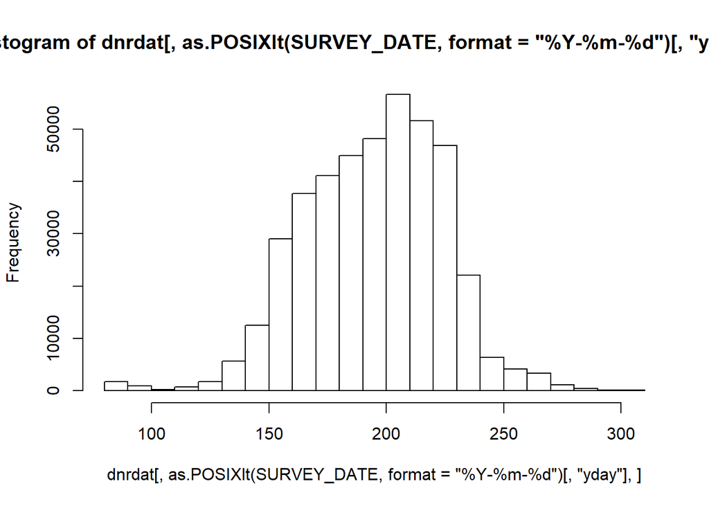

```r
    hist(dnrdat[ ,  as.POSIXlt(SURVEY_DATE, format = "%Y-%m-%d")[, "yday"],])
```

```r
# resolve substrates ------------------------------------------------------
```

### Review substrates data

```r
    dnrdat[ , str(SUBSTRATE) ,]
```

```
##  chr [1:417170] "" "" "" "" "" "" "" "" "" "" "" "" "" "" "" "" "" "" ...
```

```r
    dnrdat[ , SUBSTRATE := as.factor(tolower(SUBSTRATE)) ,]
    dnrdat[ , summary(SUBSTRATE) ,]
```

```
##                            muck            silt            sand
##          301807           42560           21991           20378
##            marl             mud            soft          gravel
##            4656            3432            3184            2414
##          rubble       sand/silt            hard        detritus
##            2171            2114            1411            1046
##       muck/sand      loose muck       firm muck         boulder
##             682             594             592             445
##   muck/detritus   muck/mud/sand            clay       very soft
##             437             408             373             328
##       silt/sand       silt/muck           sandy       muck/marl
##             282             258             256             188
##        silt/mud            firm       muck/silt       firm silt
##             169             164             160             145
## muck & detritus           silty               m        mud/muck
##             139             137             112             111
##     sand / silt              sm     5+ ft. muck      sandy muck
##             108             107             100              94
##       soft muck       silt-sand  muck over sand            rock
##              93              92              89              85
##      solid silt        firm mud        3'+ muck        mud/sand
##              85              80              76              67
##            loam       muck/hard    uncons. muck     silt / muck
##              66              56              54              53
##   muck/sand mix               s      3 ft. silt       sand/muck
##              51              50              49              48
##     silt / sand semi-soft botto    3.5 ft. silt       hard sand
##              48              47              45              45
## muck / detritus        3"" silt      loose silt      silty muck
##              45              44              44              43
##       silt/1.5'    2' firm muck      silt/1.75'     silt & muck
##              42              41              41              39
##     3+ ft. muck       1 ft silt         silt/1'   1'+ firm silt
##              38              36              36              35
##  muck/silt/marl   hard pack mud     2+ ft. muck     4+ ft. muck
##              33              30              29              28
##         muck-1'      1 ft. silt      2 ft. silt         silt 1'
##              27              25              25              25
##     muck / sand  unconsolidated      sandy/muck        2'+ muck
##              24              24              23              22
##    2.5 ft. silt      4 ft. silt    .75 ft. silt       3 ft silt
##              22              22              20              20
##     sand/gravel  2'+ loose muck 3+ ft soft muck   sandy & rocky
##              20              19              19              19
##   2' loose muck       hard muck             m/s        mud/silt
##              18              18              18              18
##       silt/marl       silt/rock         silt/2'        silt/3""
##              18              18              17              17
##        silt/8"" hrd pck mud/muc    silt on muck         (Other)
##              17              16              16            1187
```

We’ll leave this alone for now until we decide it is useful or needed data.

```r
# resolve depth data ------------------------------------------------------
```

### Review depth data

```r
    dnrdat[ , summary(DEPTH_FT), ]
```

```
##    Min. 1st Qu.  Median    Mean 3rd Qu.    Max.    NA's
##   0.000   3.000   4.500   5.934   7.200 651.000    2164
```

```r
    dnrdat[ DEPTH_FT > 99 , , ]
```

```
##     DOWLKNUM  LAKE_NAME        SURVEY_ID SURVEY_DATE STA_NBR DEPTH_FT
##  1: 11040000       Jack 1170715030146007  2007-06-11     149      106
##  2: 11040000       Jack 1170715030146007  2007-06-11     150      105
##  3: 21005700     Carlos 4970928033112000  2009-08-10      15      100
##  4: 21005700     Carlos 4970928033112000  2009-08-10      15      100
##  5: 21005700     Carlos 6761129837614000  2011-08-17     230      230
##  6: 21005700     Carlos 6761129837614000  2011-08-17     238      238
##  7: 34003200     Carrie 4691117958531000  2011-06-23      48      185
##  8: 34003200     Carrie 4691117958531000  2011-06-23      48      185
##  9: 41004300     Benton 5911222239097000  2012-06-12     296      296
## 10: 47004600 Washington 9921400243018001  2012-08-27     651      651
## 11: 69000400 White Iron 3280803146387892  2008-09-01     135      115
##     SUBSTRATE                  TAXON   TAXACODE    DATASOURCE     UTMX
##  1:                     No Veg Found novegfound DNR Fisheries 390177.0
##  2:                     No Veg Found novegfound DNR Fisheries 390177.0
```

[output cut: 21 more lines]

```r
    dnrdat[ is.na(DEPTH_FT), , ]
```

```
##       DOWLKNUM    LAKE_NAME SURVEY_ID SURVEY_DATE STA_NBR DEPTH_FT
##    1: 01009700     Newstrom      4315  2009-07-31       3       NA
##    2: 01009700     Newstrom      4315  2009-07-31       3       NA
##    3: 01009700     Newstrom      4315  2009-07-31       3       NA
##    4: 01009700     Newstrom      4315  2009-07-31       3       NA
##    5: 01009700     Newstrom      4315  2009-07-31       3       NA
##   ---
## 2160: W0889002 Trettle Pool      4715  2009-08-10      10       NA
## 2161: W0889002 Trettle Pool      4715  2009-08-10      10       NA
## 2162: W0889002 Trettle Pool      4715  2009-08-10      10       NA
## 2163: W0889002 Trettle Pool      4715  2009-08-10      10       NA
## 2164: W0889002 Trettle Pool      4715  2009-08-10      10       NA
##       SUBSTRATE                                   TAXON TAXACODE
##    1:                            Ceratophyllum demersum       CD
##    2:                                  Nuphar variegata       NV
```

[output cut: 33 more lines]

SOme of these points are good, some appear to be incorrect data entries. We’ll leave them be for no, with the assumption that we will only use complete entries in our analysis.

```r
# resolve taxa names ------------------------------------------------------
```

### Clean taxa names

```r
    dnrdat[ , sort(unique(TAXON)),]
```

```
##   [1] Acorus americanus
##   [2] Acorus calamus
##   [3] Acorus sp.
##   [4] Alisma sp.
##   [5] Alisma species
##   [6] Alisma trivale
##   [7] Alnus sp.
##   [8] Alnus species
##   [9] Andromeda glaucophylla
##  [10] Andromeda polifolia var. latifolia
##  [11] Asclepias incarnata
##  [12] Asclepias incarnata var incarnata
##  [13] Asteraceae
##  [14] Azolla mexicana
##  [15] Betula pumila
```

[output cut: 275 more lines]

```r
    dnrdat[ TAXON == "Bidens species"|
             TAXON == "Bidens sp.", TAXON := "Bidens spp.",]
    dnrdat[ TAXON == "Carex"|
              TAXON == "Carex sp.", TAXON := "Carex spp.",]
    dnrdat[ TAXON == "Chara"|
              TAXON == "Chara sp.", TAXON := "Chara spp.",]
    dnrdat <- subset(dnrdat, TAXON != "Dreissena polymorpha")
    dnrdat[ TAXON == "Drepanocladus; Fontinalis; etc", TAXON := "Drepanocladus or Fontinalis spp.",]
    dnrdat[ TAXON == "Elatine sp.", TAXON := "Elatine spp.",]
    dnrdat[ TAXON == "Eleocharis" | TAXON == "Eleocharis sp.", TAXON := "Eleocharis spp.",]
    dnrdat[ TAXON == "Elodea sp." , TAXON := "Elodea spp.",]
    dnrdat[ TAXON == "Equisetum sp.", TAXON := "Equisetum spp.",]
    dnrdat[ TAXON == "Impatiens sp.", TAXON := "Impatiens spp.",]
    dnrdat[ TAXON == "Iris sp." | TAXON == "Iris species" | TAXON == "Iris", TAXON := "Iris spp.",]
    dnrdat[ TAXON == "Isoetes sp." | TAXON == "Isoetes", TAXON := "Isoetes spp.",]
    dnrdat[ TAXON == "Juncus sp." , TAXON := "Juncus spp.",]
    dnrdat[ TAXON == "Labiatae Family" , TAXON := "Labiatae spp.",]
    dnrdat[ TAXON == "Lemna sp." | TAXON == "Lemna", TAXON := "Lemna spp.",]
    dnrdat[ TAXON == "Myriophyllum sp." | TAXON == "Myriophyllum species"| TAXON == "Myriophyllum", TAXON := "Myriophyllum spp.",]
    dnrdat[ TAXON == "Myriophyllum verticullatum" , TAXON := "Myriophyllum verticillatum",]
    dnrdat[ TAXON == "Najas sp." | TAXON == "Najas species"| TAXON == "Najas", TAXON := "Najas spp.",]
    dnrdat[ TAXON == "Nitella sp." | TAXON == "Nitella", TAXON := "Najas spp.",]
    dnrdat[ TAXON == "Nuphar sp." | TAXON == "Nuphar species", TAXON := "Nuphar spp.",]
    dnrdat[ TAXON == "Nymphaea sp.", TAXON := "Nymphaea spp.",]
    dnrdat[ TAXON == "Persicaria species - floating-leaf type" |
              TAXON == "Persicaria species" |
              TAXON == "Persicaria sp.", TAXON := "Persicaria spp.",]
    dnrdat[ TAXON == "Potamogeton Friesii"  , TAXON := "Potamogeton friesii",]
    dnrdat[ TAXON == "Potamogeton Richardsonii"  , TAXON := "Potamogeton richardsonii",]
    dnrdat[ TAXON == "Potamogeton Robbinsii"  , TAXON := "Potamogeton robbinsii",]
    dnrdat[ TAXON == "Potamogeton sp." |
              TAXON == "Potamogeton", TAXON := "Potamogeton spp.",]
    dnrdat[ TAXON == "Potamogeton species - broadleaf type"  , TAXON := "Potamogeton sp. Broad",]
    dnrdat[ TAXON == "Potamogeton species - narrowleaf type"  , TAXON := "Potamogeton sp. Narrow",]
    dnrdat[ TAXON == "Ranunculus" | TAXON == "Ranunculus sp."  , TAXON := "Ranunculus spp.",]
    dnrdat[ TAXON == "Sagittaria" | TAXON == "Sagittaria species" | TAXON == "Sagittaria sp."  , TAXON := "Sagittaria spp.",]
    dnrdat[ TAXON == "Salix sp." | TAXON == "Salix species"  , TAXON := "Salix spp.",]
    dnrdat[ TAXON == "Schoenoplectus" | TAXON == "Schoenoplectus species"  , TAXON := "Schoenoplectus spp.",]
    dnrdat[ TAXON == "Solidago sp." , TAXON := "Solidago spp.",]
    dnrdat[ TAXON == "Sparganinm sp." | TAXON == "Sparganium" |
              TAXON == "Sparganium sp." | TAXON == "Sparganium species"  , TAXON := "Sparganium spp.",]
    dnrdat[ TAXON == "Stuckenia (Potamogeton) vaginata" , TAXON := "Stuckenia vaginata",]
    dnrdat[ TAXON == "Stuckenia species" , TAXON := "Stuckenia spp.",]
    dnrdat[ TAXON == "Typha" | TAXON == "Typha species" | TAXON == "Typha sp.", TAXON := "Typha spp.",]
    dnrdat[ TAXON == "Utricularia sp." | TAXON == "Utricularia species" , TAXON := "Utricularia spp.",]
    dnrdat[ TAXON == "Wolffia sp." | TAXON == "Wolffia" , TAXON := "Wolffia spp.",]
    dnrdat[ TAXON == "Zanichellia palustris" , TAXON := "Zannichellia palustris",]
    dnrdat[ TAXON == "Unknown emergent" , TAXON := "Unknown emergent species",]
    dnrdat[ TAXON == "Alnus sp." | TAXON == "Alnus species" , TAXON := "Alnus spp.",]
    dnrdat[ TAXON == "Graminae"  , TAXON := "Gramineae/Poaceae Family",]
    dnrdat[ TAXON == "Phragmites australis (communis)"  , TAXON := "Phragmites australis",]
    dnrdat[ TAXON == "Schoenoplectus pungens/torreyi"  , TAXON := "Schoenoplectus pungens or torreyi",]
    dnrdat[ TAXON == "Sedge sp."  , TAXON := "Carex spp.",]

    dnrdat[ TAXON == "Schoenoplectus pungens/torreyi"  , TAXON := "Schoenoplectus pungens or torreyi",]




    dnrdat [ , TAXON := droplevels(TAXON),]
    dnrdat[ , sort(unique(as.character(TAXON))),]
```

```
##   [1] "Acorus americanus"
##   [2] "Acorus calamus"
##   [3] "Acorus sp."
##   [4] "Alisma sp."
##   [5] "Alisma species"
##   [6] "Alisma trivale"
##   [7] "Alnus spp."
##   [8] "Andromeda glaucophylla"
##   [9] "Andromeda polifolia var. latifolia"
##  [10] "Asclepias incarnata"
##  [11] "Asclepias incarnata var incarnata"
##  [12] "Asteraceae"
##  [13] "Azolla mexicana"
##  [14] "Betula pumila"
##  [15] "Bidens beckii"
```

[output cut: 218 more lines]

```r
# review dataset and export -----------------------------------------------
```

## Review and Export dataset

```r
    str(dnrdat)
```

```
## Classes 'data.table' and 'data.frame':   416776 obs. of  16 variables:
##  $ DOWLKNUM         : chr  "01001600" "01001600" "01001600" "01001600" ...
##  $ LAKE_NAME        : chr  "Little Prairie" "Little Prairie" "Little Prairie" "Little Prairie" ...
##  $ SURVEY_ID        : chr  "4664" "4664" "4664" "4664" ...
##  $ SURVEY_DATE      : chr  "2011-08-16" "2011-08-16" "2011-08-16" "2011-08-16" ...
##  $ STA_NBR          : int  1 1 2 3 4 5 5 6 7 8 ...
##  $ DEPTH_FT         : num  3.75 3.75 5.75 6 6 5 5 5.25 6.25 7 ...
##  $ SUBSTRATE        : Factor w/ 326 levels "",".25 ft. silt",..: 1 1 1 1 1 1 1 1 1 1 ...
##  $ TAXON            : Factor w/ 233 levels "Acorus americanus",..: 28 204 105 105 105 39 139 39 105 105 ...
##  $ TAXACODE         : chr  "CD" "VA" "EMT" "EMT" ...
##  $ DATASOURCE       : chr  "Muthukrishnan Et al" "Muthukrishnan Et al" "Muthukrishnan Et al" "Muthukrishnan Et al" ...
##  $ UTMX             : num  NA NA NA NA NA NA NA NA NA NA ...
##  $ UTMY             : num  NA NA NA NA NA NA NA NA NA NA ...
##  $ SURVEYOR         : chr  NA NA NA NA ...
##  $ SAMPLE_NOTES     : Factor w/ 383 levels "","001","002",..: NA NA NA NA NA NA NA NA NA NA ...
##  $ SAMPLE_TYPE_DESCR: Factor w/ 7 levels "no sample - emergents",..: NA NA NA NA NA NA NA NA NA NA ...
##  $ secchi_ft        : num  2 2 2.25 2.25 2.5 2.25 2.25 2.25 2.5 2.25 ...
##  - attr(*, ".internal.selfref")=<externalptr>
##  - attr(*, "sorted")= chr  "DOWLKNUM" "LAKE_NAME" "SURVEY_ID"
```

```r
    dnrdat [ , SUBSTRATE := droplevels(SUBSTRATE),]
    dnrdat [ , SAMPLE_TYPE_DESCR := droplevels(SAMPLE_TYPE_DESCR),]

    dnrdat[ , .N , TAXON] #n occurrences by spp
```

```
##                                         TAXON     N
##   1:                   Ceratophyllum demersum 38115
##   2:                    Vallisneria americana  6710
##   3:                             No Veg Found 83701
##   4:         Drepanocladus or Fontinalis spp.   850
##   5:                    Potamogeton robbinsii  6016
##  ---
## 229:                        Rumex orbiculatus    13
## 230:                           Eutrochium sp.     2
## 231:                          Cicuta maculata     1
## 232:                       Veronica americana     1
## 233: Bolboschoenus maritimus subsp. Paludosus     2
```

```r
    dnrdat[ , .N , c("SURVEY_ID","DATASOURCE")] #n obseravtion in each survey (total lines = n surveys)
```

```
##       SURVEY_ID          DATASOURCE   N
##    1:      4664 Muthukrishnan Et al  63
##    2:      4643 Muthukrishnan Et al 126
##    3:      5131 Muthukrishnan Et al 160
##    4:      5257 Muthukrishnan Et al 147
##    5:      4290 Muthukrishnan Et al 118
##   ---
## 2069:      3105 Muthukrishnan Et al  31
## 2070:      3106 Muthukrishnan Et al 109
## 2071:      4711 Muthukrishnan Et al 175
## 2072:      4715 Muthukrishnan Et al 328
## 2073:      4967 Muthukrishnan Et al   8
```

```r
    dnrdat[ , length(unique(SURVEY_ID)) , DATASOURCE ] #nsurveys submitted by each DNR contributor
```

```
##              DATASOURCE   V1
## 1:  Muthukrishnan Et al 1668
## 2:        DNR Fisheries  258
## 3: DNR Lakes and Rivers  147
```

```r
    names(dnrdat)[3] <- "SURVEY_ID_DATASOURCE"
    names(dnrdat)[16] <- "POINT_LVL_SECCHI"

    #create new, unique survey ID for each survey
    dnrdat[ , .N , c("SURVEY_ID_DATASOURCE","DATASOURCE")]
```

```
##       SURVEY_ID_DATASOURCE          DATASOURCE   N
##    1:                 4664 Muthukrishnan Et al  63
##    2:                 4643 Muthukrishnan Et al 126
##    3:                 5131 Muthukrishnan Et al 160
##    4:                 5257 Muthukrishnan Et al 147
##    5:                 4290 Muthukrishnan Et al 118
##   ---
## 2069:                 3105 Muthukrishnan Et al  31
## 2070:                 3106 Muthukrishnan Et al 109
## 2071:                 4711 Muthukrishnan Et al 175
## 2072:                 4715 Muthukrishnan Et al 328
## 2073:                 4967 Muthukrishnan Et al   8
```

```r
    nrow(dnrdat[ , .N , c("SURVEY_ID_DATASOURCE","DATASOURCE")])
```

```
## [1] 2073
```

```r
    dnrdat[, SURVEY_ID := .GRP, by = c("SURVEY_ID_DATASOURCE","DATASOURCE")]

    #and a unique ID for each sample point (groups the plant obs)
    dnrdat[, POINT_ID := .GRP, by = c("STA_NBR", "SURVEY_ID_DATASOURCE", "DATASOURCE")]

    #and finally a unique ID for each observation in the dataset
    dnrdat[, OBS_ID := .I]


# metadata for this dataset -----------------------------------------------
```

### Metadata

MN DNR has 3 primary db’s with these data in them. First is shallow lakes. We can get most of that from a 2018 Muthukrishnan Et al. data archive. There are also data collected by Fisheries–these were shared by Donna Dustin. Finally, data from the Lakes and Rivers or Lakes Habitat (a.k.a Perleberg and Radomski) were acquired through a formal data request (which only turned up data collected before 2013).

Muthukrishnan, R., Hansel-Welch, N., & Larkin, D. J. (2018). Environmental filtering and competitive exclusion drive biodiversity-invasibility relationships in shallow lake plant communities. Journal of Ecology, 106(5), 2058–2070. https://doi.org/10.1111/1365-2745.12963

We joined these three datasets together, resulting in the following:

```r
    str(dnrdat)
```

```
## Classes 'data.table' and 'data.frame':   416776 obs. of  19 variables:
##  $ DOWLKNUM            : chr  "01001600" "01001600" "01001600" "01001600" ...
##  $ LAKE_NAME           : chr  "Little Prairie" "Little Prairie" "Little Prairie" "Little Prairie" ...
##  $ SURVEY_ID_DATASOURCE: chr  "4664" "4664" "4664" "4664" ...
##  $ SURVEY_DATE         : chr  "2011-08-16" "2011-08-16" "2011-08-16" "2011-08-16" ...
##  $ STA_NBR             : int  1 1 2 3 4 5 5 6 7 8 ...
##  $ DEPTH_FT            : num  3.75 3.75 5.75 6 6 5 5 5.25 6.25 7 ...
##  $ SUBSTRATE           : Factor w/ 326 levels "",".25 ft. silt",..: 1 1 1 1 1 1 1 1 1 1 ...
##  $ TAXON               : Factor w/ 233 levels "Acorus americanus",..: 28 204 105 105 105 39 139 39 105 105 ...
##  $ TAXACODE            : chr  "CD" "VA" "EMT" "EMT" ...
##  $ DATASOURCE          : chr  "Muthukrishnan Et al" "Muthukrishnan Et al" "Muthukrishnan Et al" "Muthukrishnan Et al" ...
##  $ UTMX                : num  NA NA NA NA NA NA NA NA NA NA ...
##  $ UTMY                : num  NA NA NA NA NA NA NA NA NA NA ...
##  $ SURVEYOR            : chr  NA NA NA NA ...
##  $ SAMPLE_NOTES        : Factor w/ 383 levels "","001","002",..: NA NA NA NA NA NA NA NA NA NA ...
##  $ SAMPLE_TYPE_DESCR   : Factor w/ 1 level "sampled": NA NA NA NA NA NA NA NA NA NA ...
##  $ POINT_LVL_SECCHI    : num  2 2 2.25 2.25 2.5 2.25 2.25 2.25 2.5 2.25 ...
##  $ SURVEY_ID           : int  1 1 1 1 1 1 1 1 1 1 ...
##  $ POINT_ID            : int  1 1 2 3 4 5 5 6 7 8 ...
##  $ OBS_ID              : int  1 2 3 4 5 6 7 8 9 10 ...
##  - attr(*, ".internal.selfref")=<externalptr>
##  - attr(*, "sorted")= chr  "DOWLKNUM" "LAKE_NAME" "SURVEY_ID_DATASOURCE"
```

Where: **DOWLKNUM** - MNDNR Dept of Waters unique waterbody identifier, or an identifier from NWI or other to distinguish each waterbody  
**LAKE_NAME** - Lake name as provided by data contributor, has redundancies, lake identification should default to DOWLKNUM  
**SURVEY_ID_DATASOURCE** - Unique survey IDs from each data contributor (only unique within each contributor group)  
**SURVEY_DATE** - date of observation in yyyy-mm-dd  
**STA_NBR** - identifier for each point within a point-intercept survey (not all repeated surveys are guaranteed to be repeated samples of the same geo- locations if looking for repeat sampling of individual points through time, carefully consider X,Y coords where avail and total *n* points in each survey to be sure repeated samples targeted same locs)  
**DEPTH_FT** - depth observed at each sample location, measured in various methods including depth pole/probe, weighted rope, sonar, etc. These data have not been cleaned and may contain errors (see *Review depth data* section above)  
**SUBSTRATE** - sustrate observations from surveys collected IAW: Perleberg, D., P. Radomski, S. Simon, K. Carlson, and J. Knopik. 2016. Minnesota Lake Plant Survey Manual, for use by MNDNR Fisheries Section and EWR Lake Habitat Program. Minnesota Department of Natural Resources. Ecological and Water Resources Division. Brainerd, MN. 128 pages including Appendices A-E.

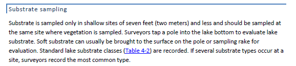

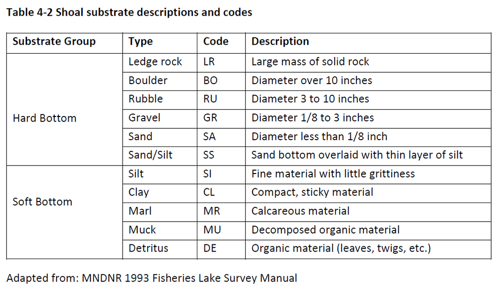

**TAXON** - Scientific name of taxa observed. Note that higher taxa classes are used when surveyors are unable to identify taxa to the species level. Each taxon observation is classified to the lowest level possible by surveyor  
**TAXACODE** - These are codes used by each datasource for taxa names. If using these codes, note that they may differ among datasources and this script has used keys supplied by each datasource to develop the **TAXON** field from those keys  
**DATASOURCE** - Group supplying the data for this collation effort  
**UTMX** - X component of UTM location (datum: 83, zone: 15). We have not evaluated the quality or consistency of these data  
**UTMY** - Y component of UTM location (datum: 83, zone: 15). We have not evaluated the quality or consistency of these data  
**SURVEYOR** - Name of surveyor or surveying entity, where provided  
**SAMPLE_NOTES** - Notes associated with each observation  
**SAMPLE_TYPE_DESCR** - used in Lakes and Rivers data to identify shoreline plots and regular PI plots.

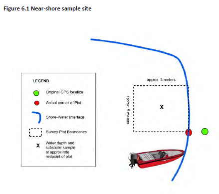

See:  
Perleberg, D., P. Radomski, S. Simon, K. Carlson, and J. Knopik. 2016. Minnesota Lake Plant Survey Manual, for use by MNDNR Fisheries Section and EWR Lake Habitat Program. Minnesota Department of Natural Resources. Ecological and Water Resources Division. Brainerd, MN. 128 pages including Appendices A-E.  
**POINT_LVL_SECCHI** - Secchi observations taxen at samling locations as collected only in the Muthukrishnan Et al dataset.  
**SURVEY_ID** - Unique ID assigned to each survey in this dataset  
**POINT_ID** - Unique ID asisgned to each point in this dataset (aggregates osbervations of taxa within each point)  
**OBS_ID** - Unique ID for each observation in this dataset

### Export data

```r
    # write.csv(dnrdat, file = "data/output/DNR_PI_Data_Combined.csv")

  # footer ------------------------------------------------------------------
```

## Document footer

Session Information:

```r
  #script runtime
  Sys.time() - strttime
```

```
## Time difference of 43.99637 secs
```